# SEACAR SAV Analysis

# Cockroach Bay Aquatic Preserve

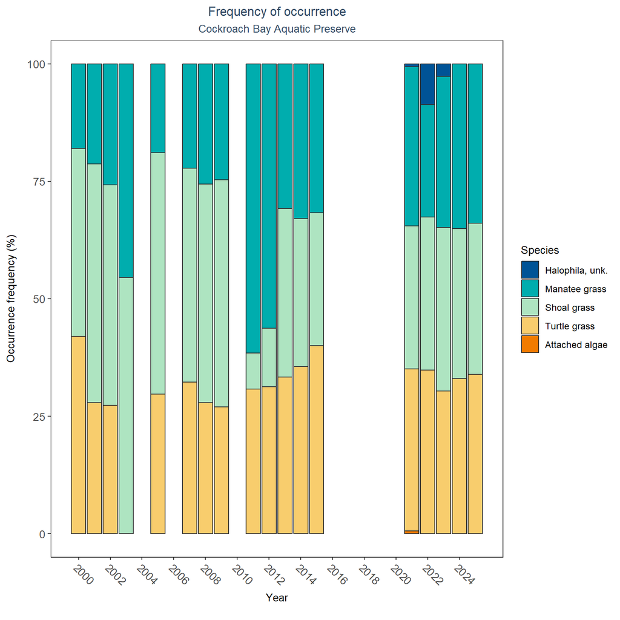

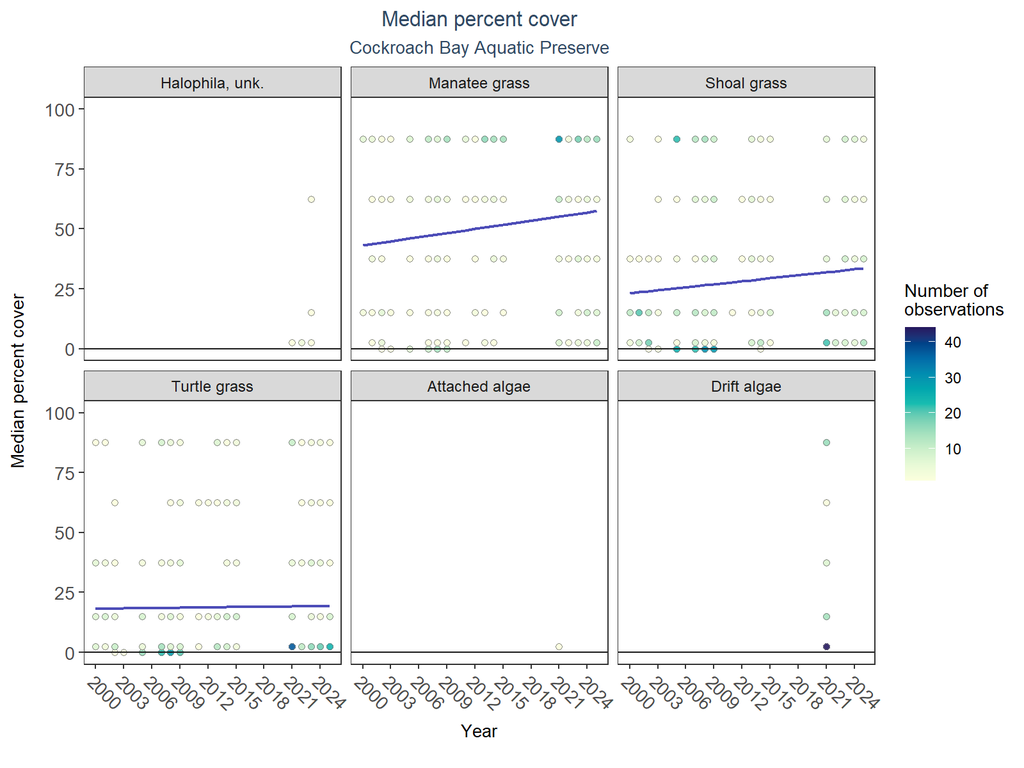

SAV LME Results for Cockroach Bay Aquatic Preserve

| Species | Statistical Trend | Period of Record | LME Intercept | LME Slope | p |
| --- | --- | --- | --- | --- | --- |
| Attached algae | Insufficient data | 2021 - 2021 | - | - | - |
| Drift algae | Insufficient data | 2021 - 2021 | - | - | - |
| Shoal grass | No detectable trend | 2000 - 2025 | 20.69 | 0.42 | 0.05 |
| Manatee grass | Increasing trend | 2000 - 2025 | 39.66 | 0.57 | 0.02 |
| Turtle grass | No detectable trend | 2000 - 2025 | 17.87 | 0.05 | 0.80 |
| Halophila, unk. | Insufficient data | 2021 - 2023 | - | - | - |

An annual increase in percent cover was observed for manatee grass (0.57%). No detectable change in percent cover was observed for shoal grass and turtle grass. Trends in percent cover could not be evaluated for unknown *Halophila*, attached algae, and drift algae due to insufficient data.

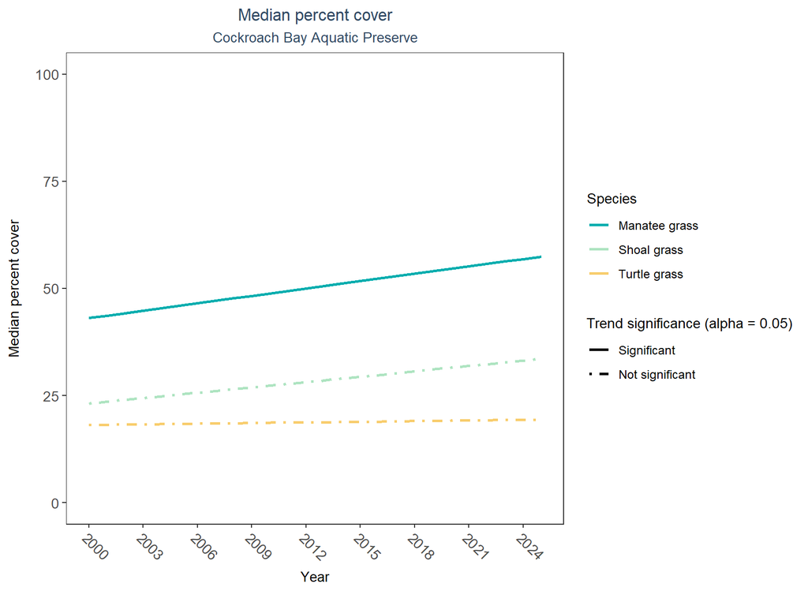

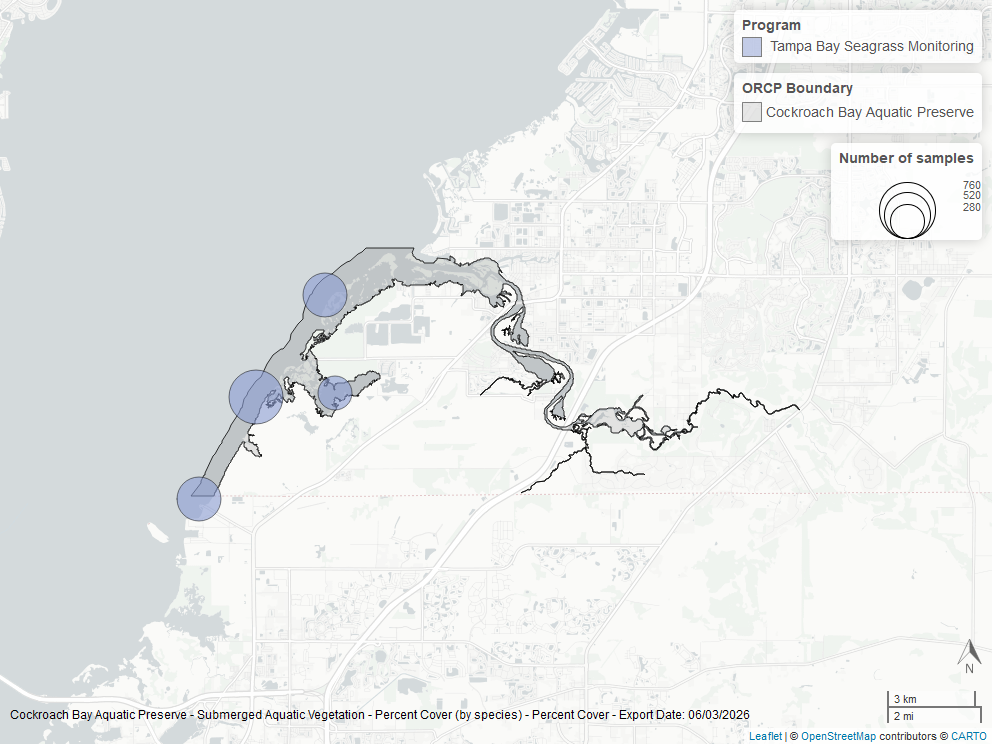

Map showing SAV sampling sites within the boundaries of *Cockroach Bay Aquatic Preserve*. The point size reflects the number of samples at a given sampling site.

# Estero Bay Aquatic Preserve

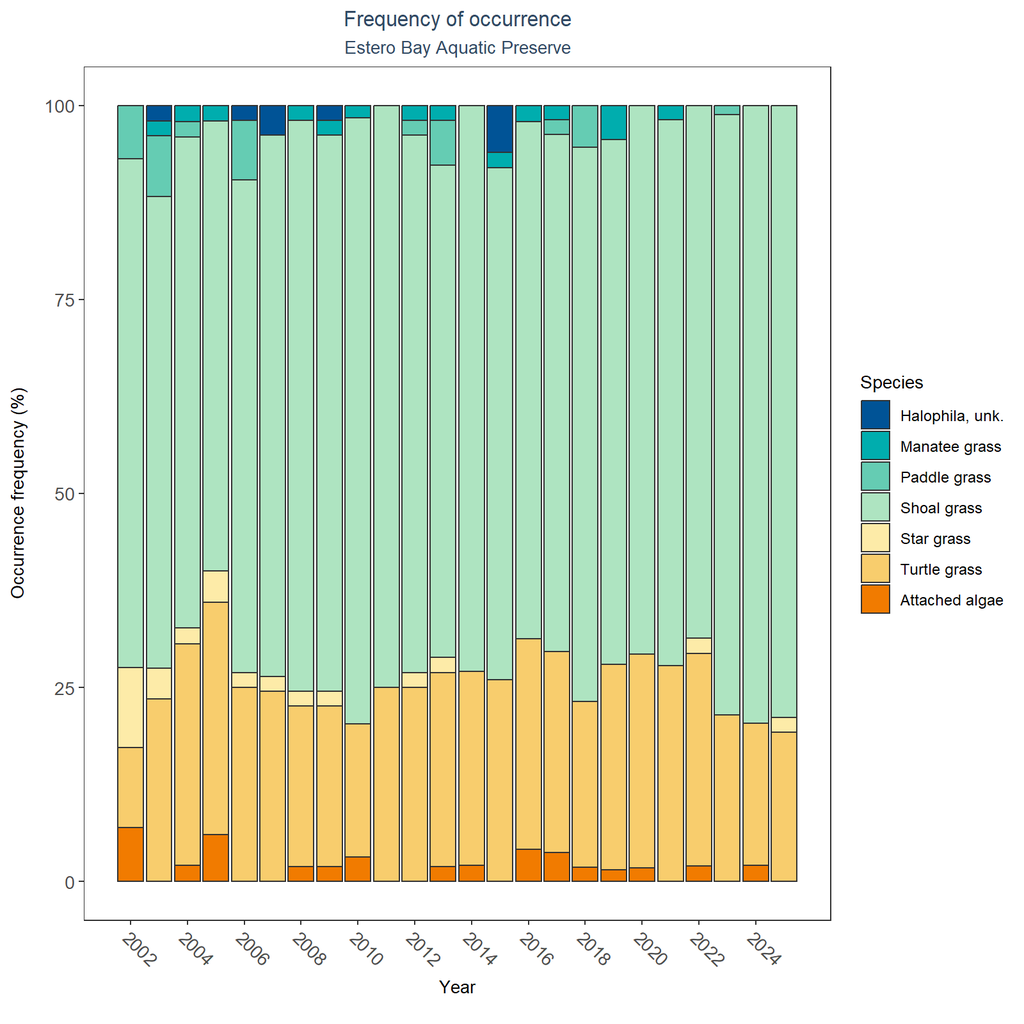

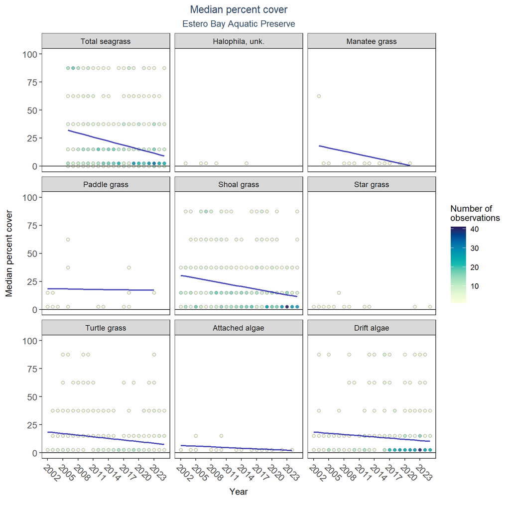

SAV LME Results for Estero Bay Aquatic Preserve

| Species | Statistical Trend | Period of Record | LME Intercept | LME Slope | p |
| --- | --- | --- | --- | --- | --- |
| Attached algae | No detectable trend | 2002 - 2024 | 8.13 | -0.20 | 0.39 |
| Drift algae | No detectable trend | 2002 - 2025 | 21.42 | -0.36 | 0.23 |
| Shoal grass | Decreasing trend | 2002 - 2025 | 37.00 | -0.82 | 0.00 |
| Paddle grass | No detectable trend | 2002 - 2023 | 18.90 | -0.06 | 0.92 |
| Star grass | Model did not fit the available data | 2002 - 2025 | - | - | - |
| Manatee grass | No detectable trend | 2003 - 2021 | 26.94 | -0.97 | 0.35 |
| Turtle grass | Decreasing trend | 2002 - 2025 | 22.48 | -0.48 | 0.01 |
| Total seagrass | Decreasing trend | 2006 - 2025 | 46.37 | -1.20 | 0.03 |
| Halophila, unk. | Model did not fit the available data | 2003 - 2015 | - | - | - |

Annual decreases in percent cover were observed for total seagrass (-1.20%), shoal grass (-0.82%), and turtle grass (-0.48%). Manatee grass, paddle grass, attached algae, and drift algae showed no detectable change in percent cover. A model could not be fitted for unknown *Halophila* and star grass.

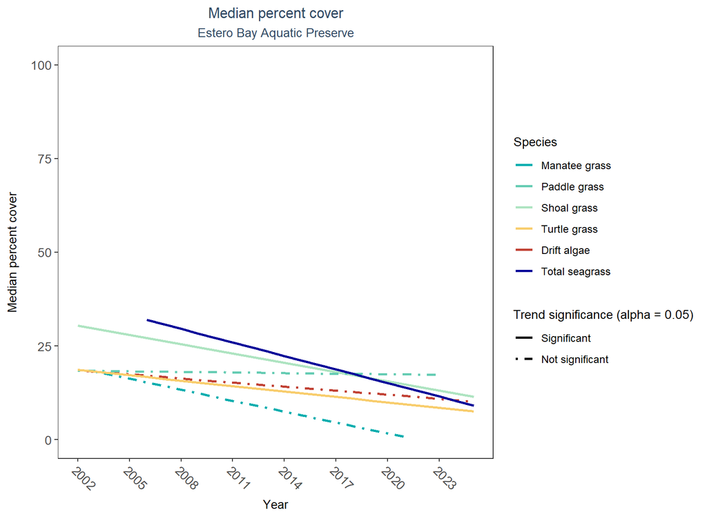

[figure not shown]

Map showing SAV sampling sites within the boundaries of *Estero Bay Aquatic Preserve*. The point size reflects the number of samples at a given sampling site.

# Florida Keys National Marine Sanctuary

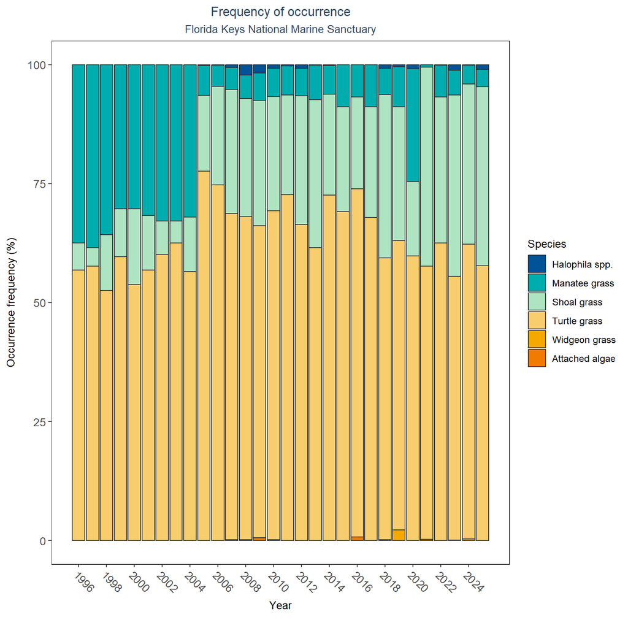

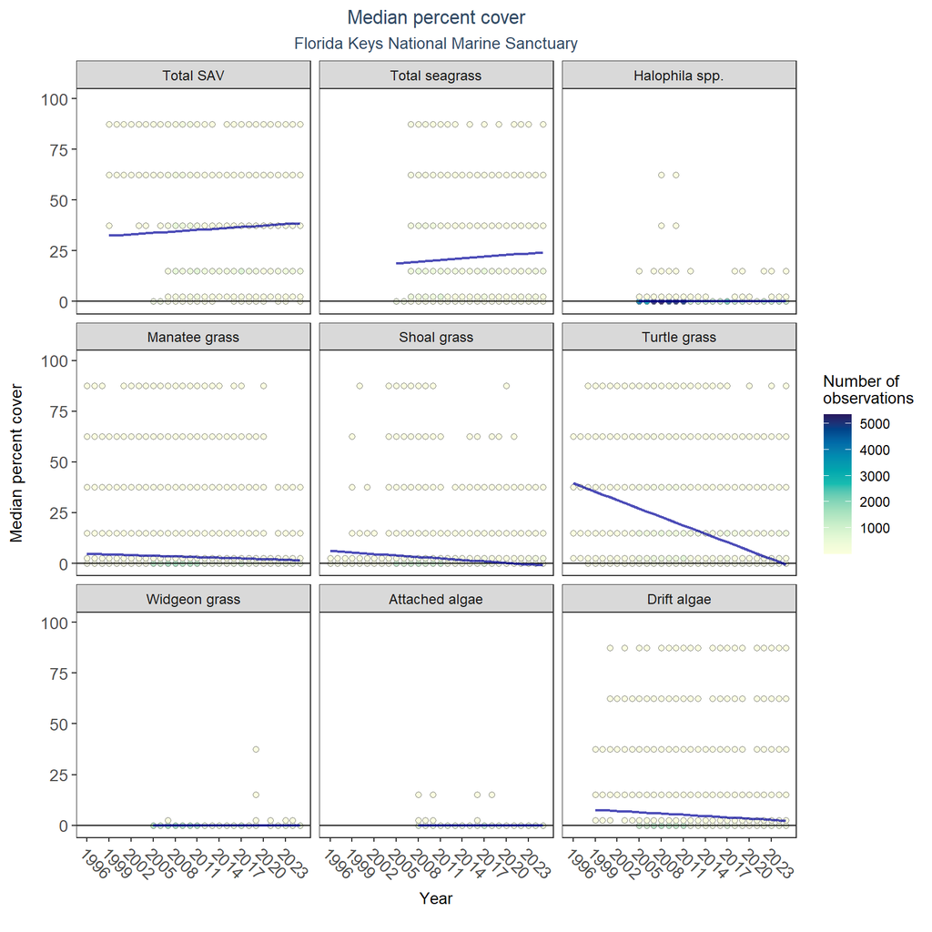

SAV LME Results for Florida Keys National Marine Sanctuary

| Species | Statistical Trend | Period of Record | LME Intercept | LME Slope | p |
| --- | --- | --- | --- | --- | --- |
| Attached algae | No detectable trend | 2008 - 2025 | 0.07 | 0.00 | 0.20 |
| Drift algae | Decreasing trend | 1999 - 2025 | 8.74 | -0.21 | 0.00 |
| Shoal grass | Decreasing trend | 1996 - 2025 | 6.66 | -0.24 | 0.00 |
| Halophila spp. | No detectable trend | 2005 - 2025 | 0.07 | 0.00 | 0.41 |
| Widgeon grass | No detectable trend | 2005 - 2025 | -0.03 | 0.00 | 0.13 |
| Manatee grass | Decreasing trend | 1996 - 2025 | 4.94 | -0.11 | 0.02 |
| Turtle grass | Decreasing trend | 1996 - 2025 | 42.29 | -1.38 | 0.00 |
| Total SAV | No detectable trend | 1999 - 2025 | 31.28 | 0.24 | 0.12 |
| Total seagrass | Increasing trend | 2005 - 2025 | 15.77 | 0.28 | 0.00 |

An annual increase in percent cover was observed for total seagrass (0.28%). Annual decreases in percent cover were observed for manatee grass (-0.11%), shoal grass (-0.24%), turtle grass (-1.38%), and drift algae (-0.21%). Total SAV, *Halophila* spp., widgeon grass, and attached algae showed no detectable change in percent cover.

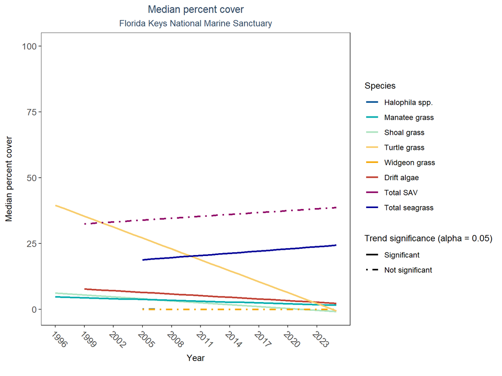

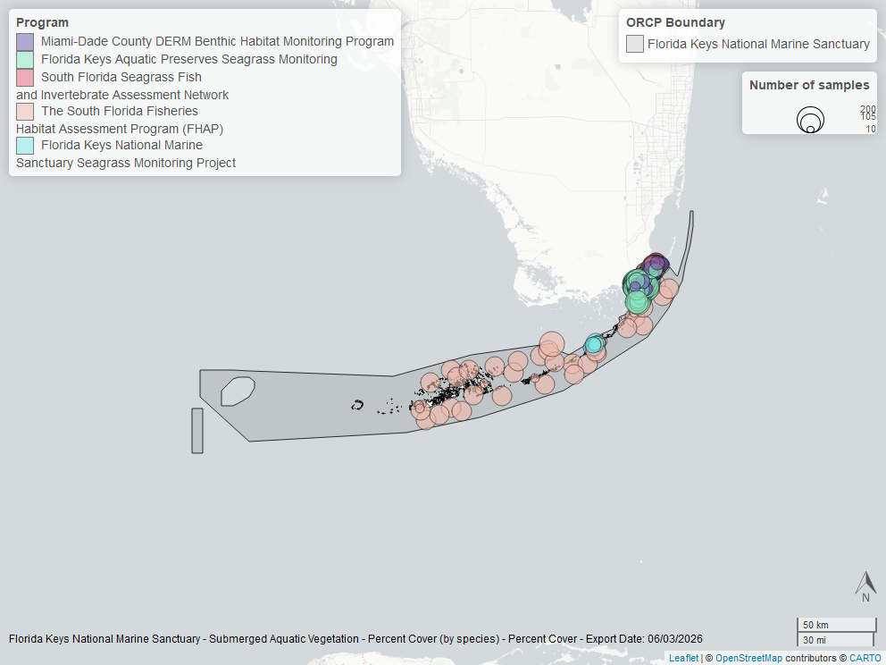

Map showing SAV sampling sites within the boundaries of *Florida Keys National Marine Sanctuary*. The point size reflects the number of samples at a given sampling site.

# Fort Pickens State Park Aquatic Preserve

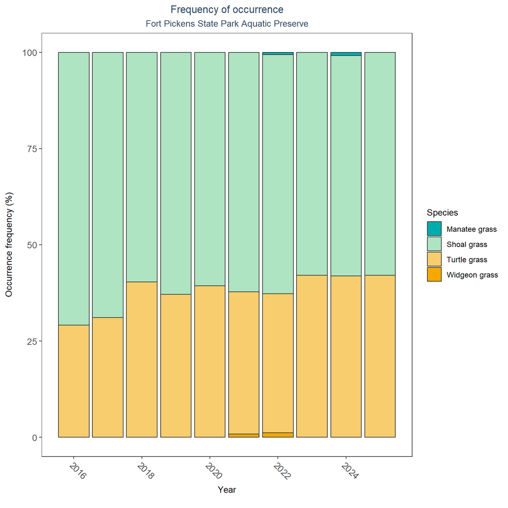

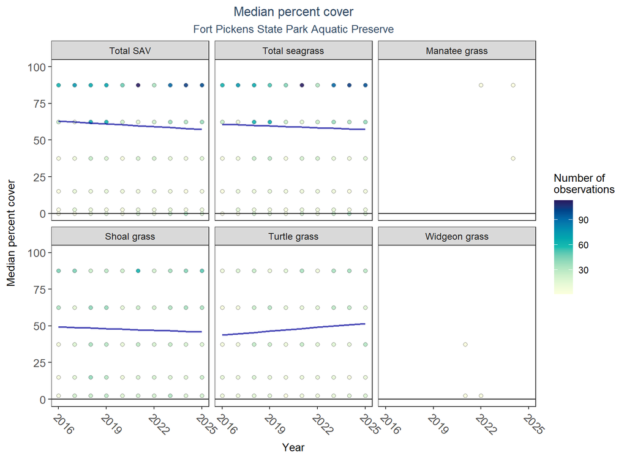

SAV LME Results for Fort Pickens State Park Aquatic Preserve

| Species | Statistical Trend | Period of Record | LME Intercept | LME Slope | p |
| --- | --- | --- | --- | --- | --- |
| Shoal grass | No detectable trend | 2016 - 2025 | 57.58 | -0.38 | 0.30 |
| Widgeon grass | Insufficient data | 2021 - 2022 | - | - | - |
| Manatee grass | Insufficient data | 2022 - 2024 | - | - | - |
| Turtle grass | No detectable trend | 2016 - 2025 | 24.56 | 0.87 | 0.14 |
| Total SAV | No detectable trend | 2016 - 2025 | 76.79 | -0.63 | 0.22 |
| Total seagrass | No detectable trend | 2016 - 2025 | 69.86 | -0.41 | 0.45 |

Total SAV, total seagrass, shoal grass, and turtle grass showed no detectable change in percent cover. Trends in percent cover could not be evaluated for manatee grass and widgeon grass due to insufficient data.

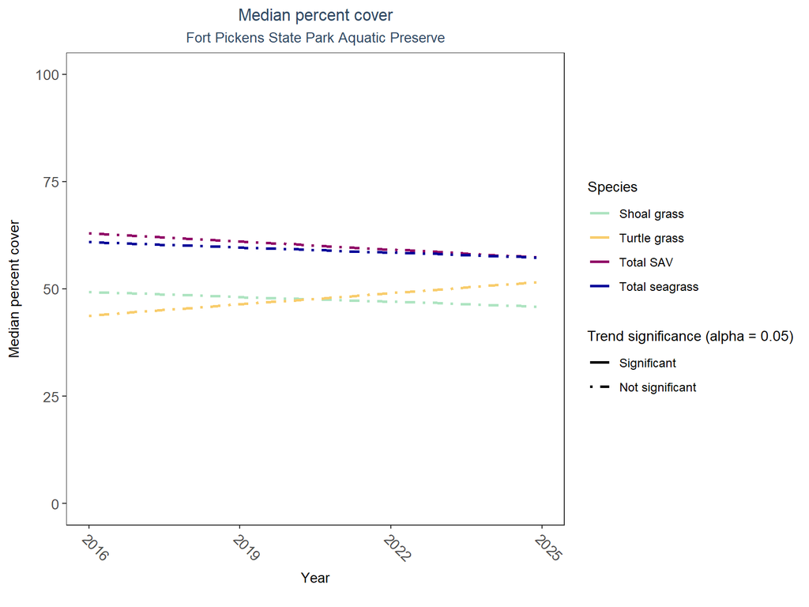

[figure not shown]

Map showing SAV sampling sites within the boundaries of *Fort Pickens State Park Aquatic Preserve*. The point size reflects the number of samples at a given sampling site.

# Gasparilla Sound-Charlotte Harbor Aquatic Preserve

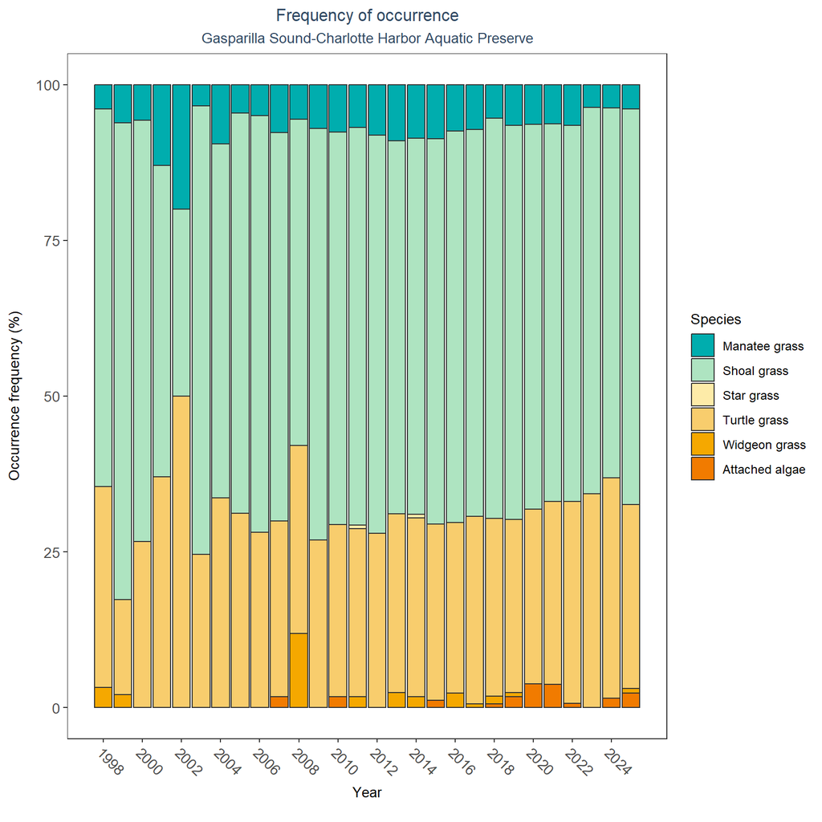

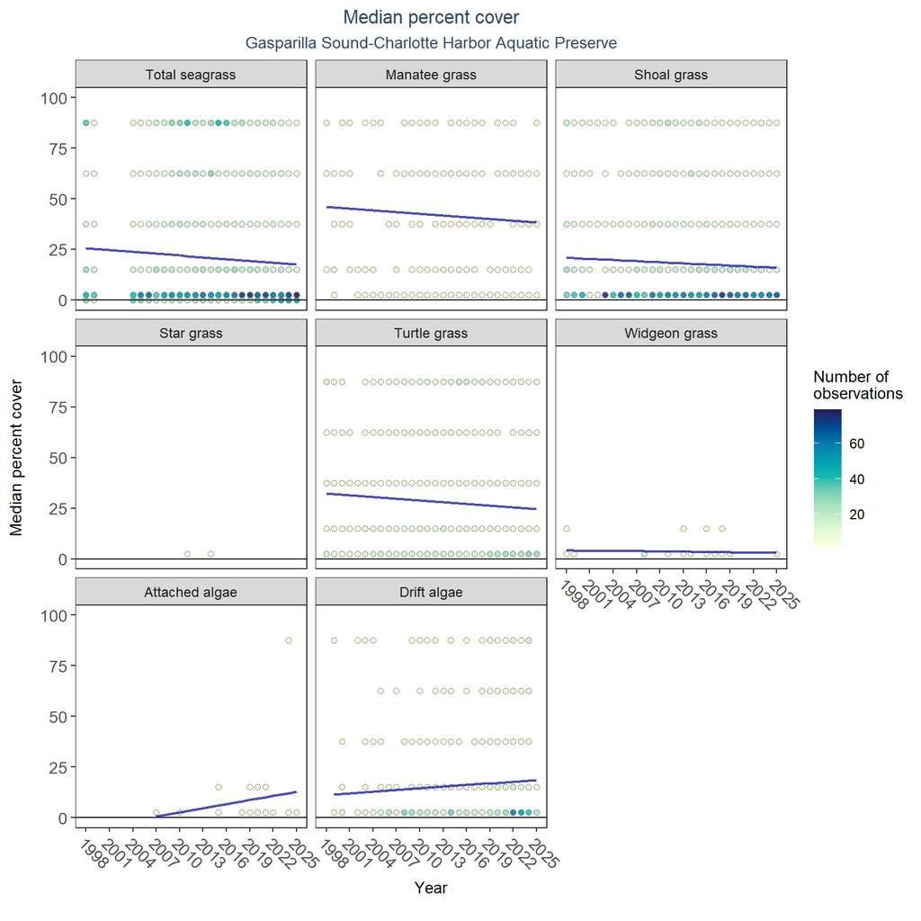

SAV LME Results for Gasparilla Sound-Charlotte Harbor Aquatic Preserve

| Species | Statistical Trend | Period of Record | LME Intercept | LME Slope | p |
| --- | --- | --- | --- | --- | --- |
| Attached algae | No detectable trend | 2007 - 2025 | -8.32 | 0.68 | 0.26 |
| Drift algae | No detectable trend | 1999 - 2025 | 9.88 | 0.28 | 0.28 |
| Shoal grass | Decreasing trend | 1998 - 2025 | 21.59 | -0.18 | 0.01 |
| Star grass | Insufficient data | 2011 - 2014 | - | - | - |
| Widgeon grass | No detectable trend | 1998 - 2025 | 4.54 | -0.05 | 0.70 |
| Manatee grass | No detectable trend | 1998 - 2025 | 47.03 | -0.28 | 0.56 |
| Turtle grass | Decreasing trend | 1998 - 2025 | 33.51 | -0.29 | 0.02 |
| Total seagrass | Decreasing trend | 1998 - 2025 | 26.78 | -0.30 | 0.00 |

Annual decreases in percent cover were observed for total seagrass (-0.30%), shoal grass (-0.18%), and turtle grass (-0.29%). Manatee grass, widgeon grass, attached algae, and drift algae showed no detectable change in percent cover. Trends in percent cover could not be evaluated for star grass due to insufficient data.

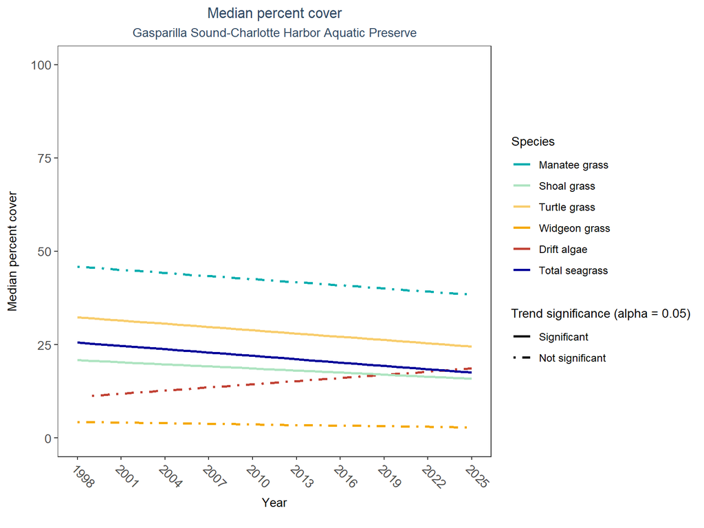

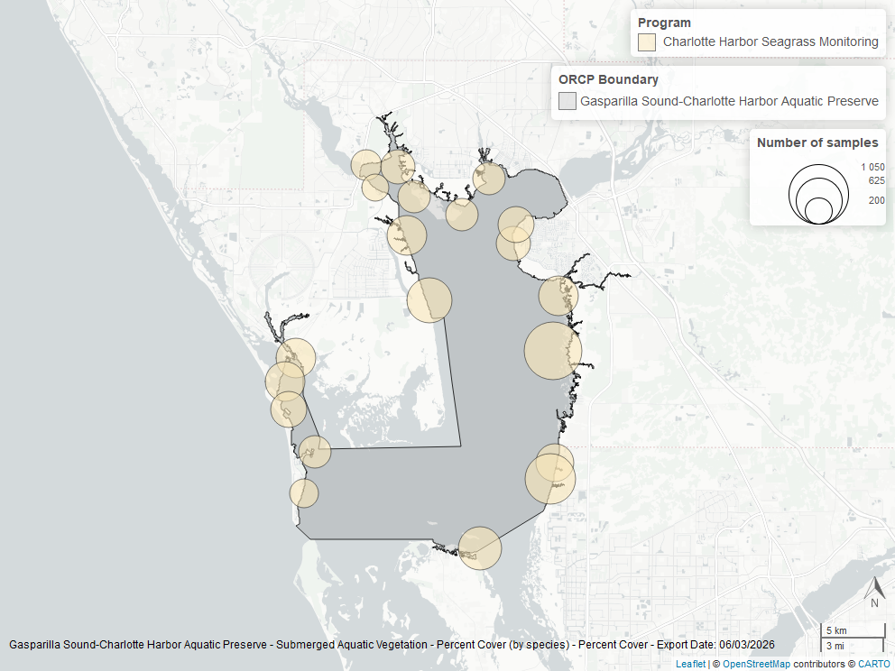

Map showing SAV sampling sites within the boundaries of *Gasparilla Sound-Charlotte Harbor Aquatic Preserve*. The point size reflects the number of samples at a given sampling site.

# Indian River-Malabar to Vero Beach Aquatic Preserve

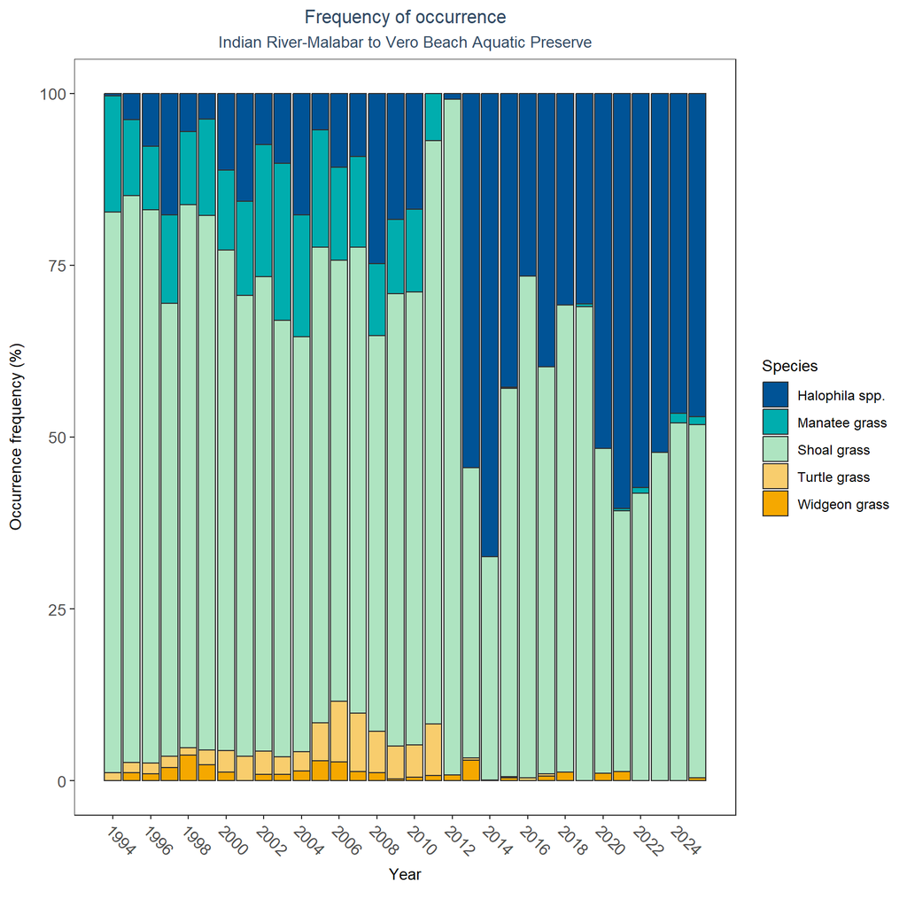

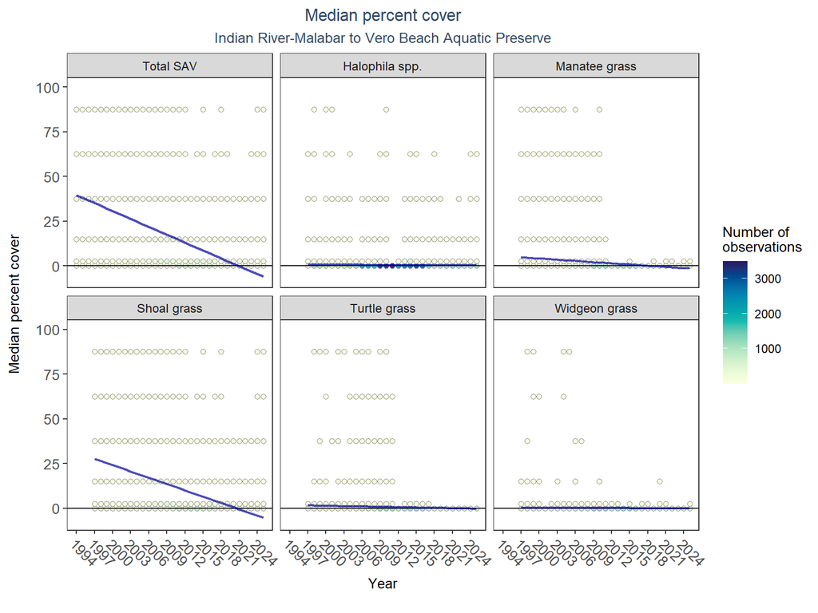

SAV LME Results for Indian River-Malabar to Vero Beach Aquatic Preserve

| Species | Statistical Trend | Period of Record | LME Intercept | LME Slope | p |
| --- | --- | --- | --- | --- | --- |
| Shoal grass | Decreasing trend | 1997 - 2025 | 31.12 | -1.17 | 0.00 |
| Halophila spp. | No detectable trend | 1997 - 2025 | 0.49 | 0.00 | 0.79 |
| Widgeon grass | No detectable trend | 1997 - 2025 | 0.24 | -0.01 | 0.10 |
| Manatee grass | Decreasing trend | 1997 - 2025 | 5.52 | -0.23 | 0.00 |
| Turtle grass | No detectable trend | 1997 - 2025 | 1.73 | -0.07 | 0.10 |
| Total SAV | Decreasing trend | 1994 - 2025 | 39.51 | -1.47 | 0.00 |

Annual decreases in percent cover were observed for total SAV (-1.47%), manatee grass (-0.23%), and shoal grass (-1.17%). *Halophila* spp., turtle grass, and widgeon grass showed no detectable change in percent cover.

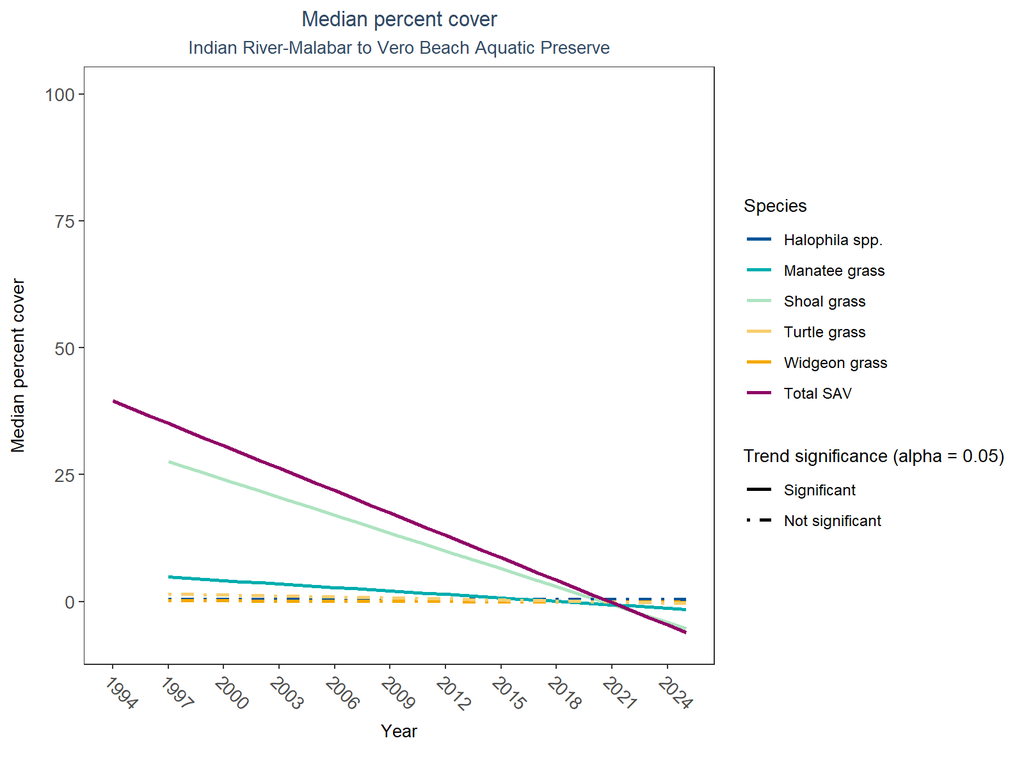

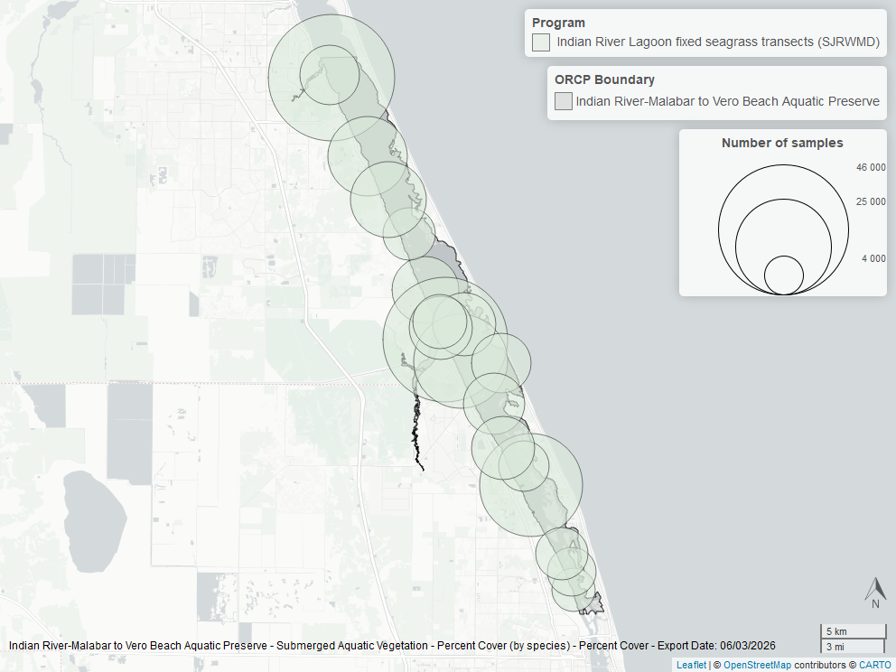

Map showing SAV sampling sites within the boundaries of *Indian River-Malabar to Vero Beach Aquatic Preserve*. The point size reflects the number of samples at a given sampling site.

# Indian River-Vero Beach to Ft. Pierce Aquatic Preserve

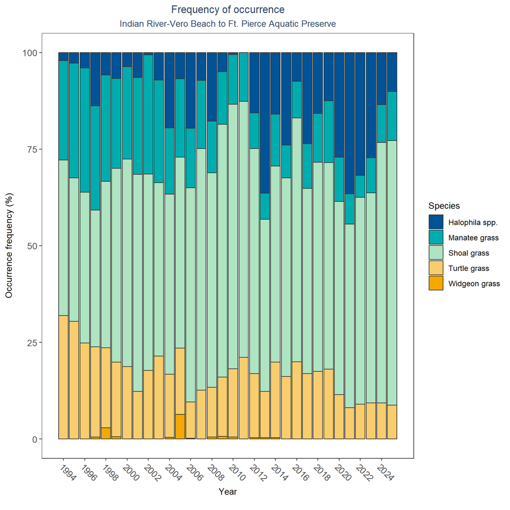

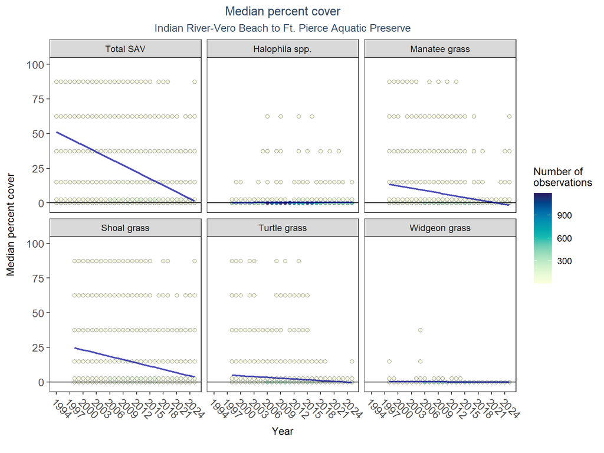

SAV LME Results for Indian River-Vero Beach to Ft. Pierce Aquatic Preserve

| Species | Statistical Trend | Period of Record | LME Intercept | LME Slope | p |
| --- | --- | --- | --- | --- | --- |
| Shoal grass | Decreasing trend | 1998 - 2025 | 27.88 | -0.78 | 0.00 |
| Halophila spp. | No detectable trend | 1998 - 2025 | 0.12 | 0.01 | 0.09 |
| Widgeon grass | No detectable trend | 1998 - 2025 | 0.13 | 0.00 | 0.12 |
| Manatee grass | Decreasing trend | 1998 - 2025 | 15.48 | -0.55 | 0.04 |
| Turtle grass | Decreasing trend | 1998 - 2025 | 5.65 | -0.19 | 0.01 |
| Total SAV | Decreasing trend | 1994 - 2025 | 51.26 | -1.60 | 0.00 |

Annual decreases in percent cover were observed for total SAV (-1.60%), manatee grass (-0.55%), shoal grass (-0.78%), and turtle grass (-0.19%). No detectable change in percent cover was observed for *Halophila* spp. and widgeon grass.

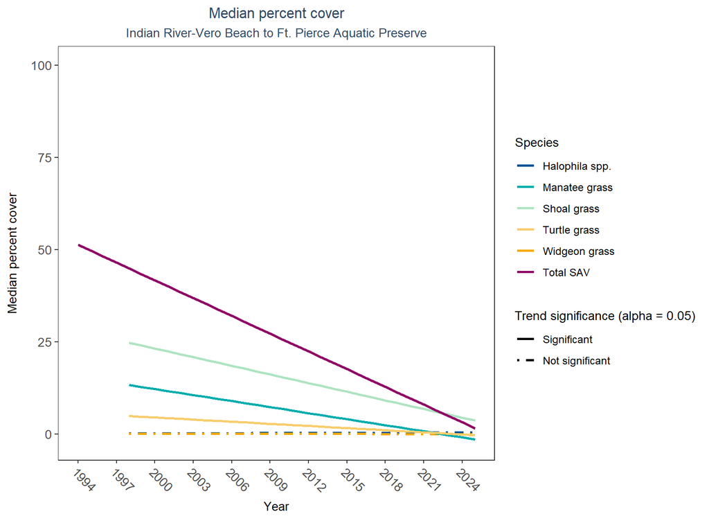

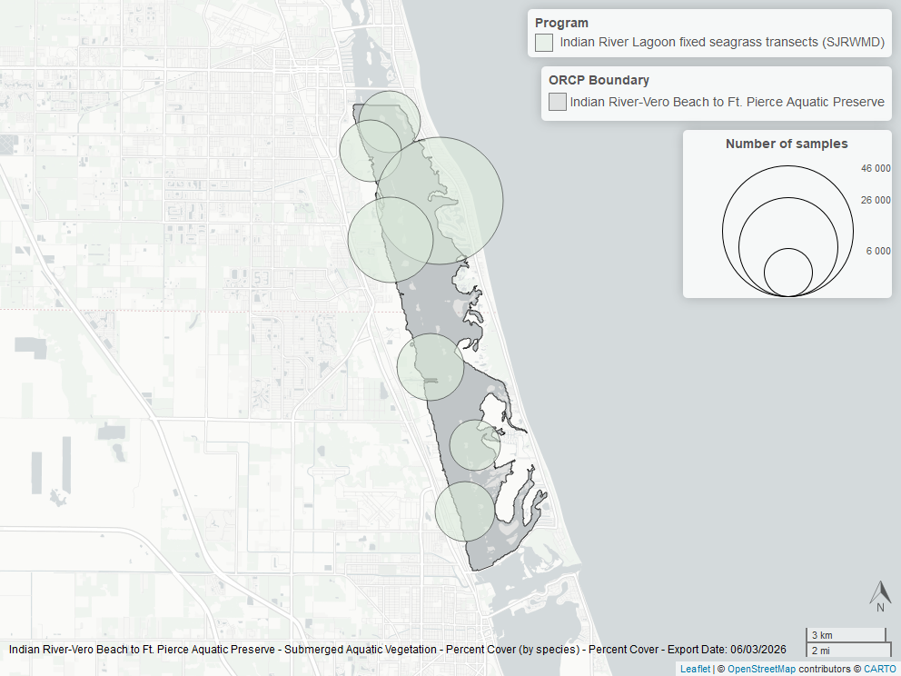

Map showing SAV sampling sites within the boundaries of *Indian River-Vero Beach to Ft. Pierce Aquatic Preserve*. The point size reflects the number of samples at a given sampling site.

# Jensen Beach to Jupiter Inlet Aquatic Preserve

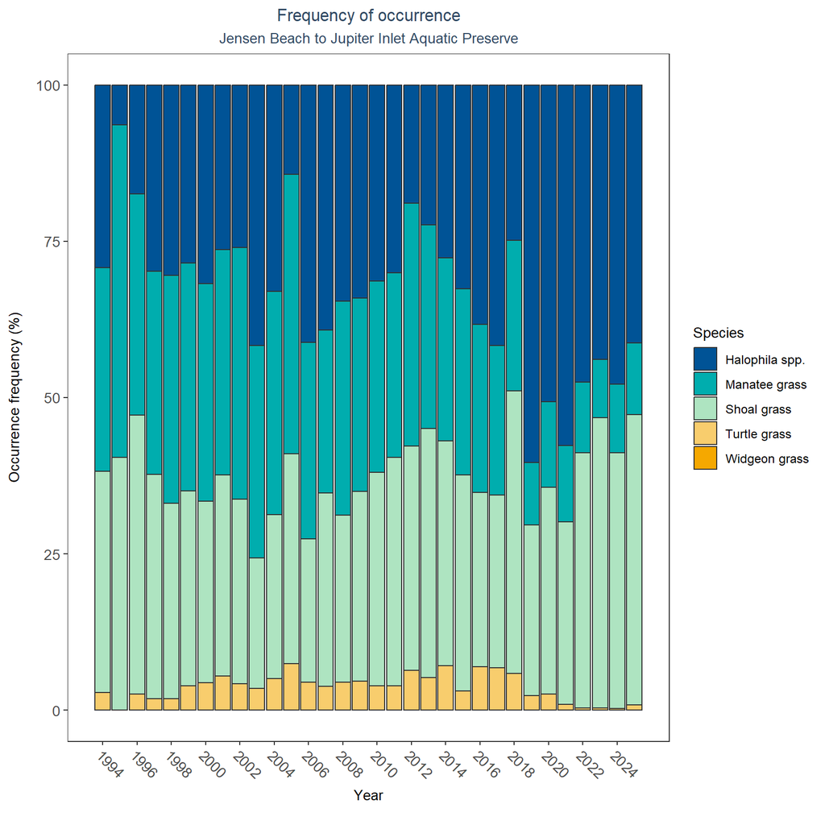

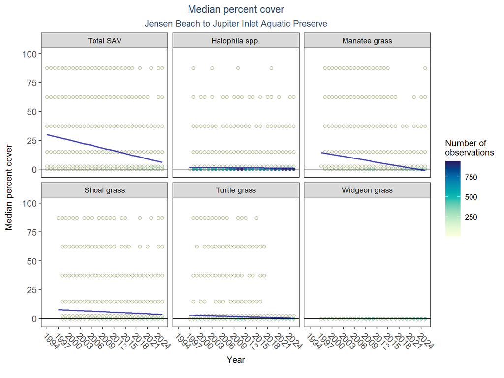

SAV LME Results for Jensen Beach to Jupiter Inlet Aquatic Preserve

| Species | Statistical Trend | Period of Record | LME Intercept | LME Slope | p |
| --- | --- | --- | --- | --- | --- |
| Shoal grass | No detectable trend | 1997 - 2025 | 8.41 | -0.15 | 0.10 |
| Halophila spp. | No detectable trend | 1997 - 2025 | 1.66 | -0.03 | 0.06 |
| Widgeon grass | Model did not fit the available data | 1997 - 2025 | - | - | - |
| Manatee grass | Decreasing trend | 1997 - 2025 | 16.27 | -0.56 | 0.00 |
| Turtle grass | No detectable trend | 1997 - 2025 | 3.16 | -0.09 | 0.07 |
| Total SAV | Decreasing trend | 1994 - 2025 | 30.00 | -0.77 | 0.00 |

Annual decreases in percent cover were observed for total SAV (-0.77%) and manatee grass (-0.56%). *Halophila* spp., shoal grass, and turtle grass showed no detectable change in percent cover. The model could not be fitted for widgeon grass.

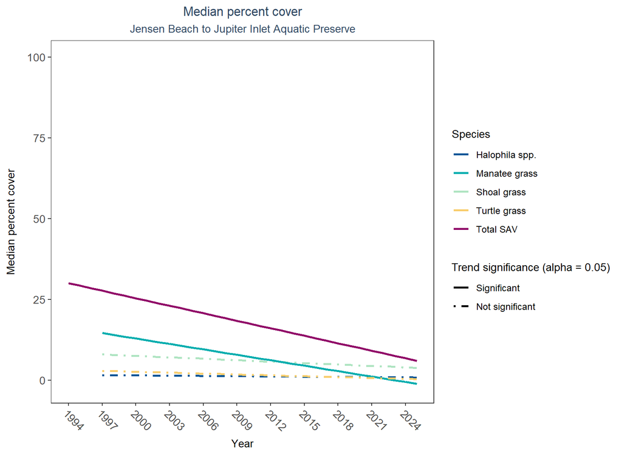

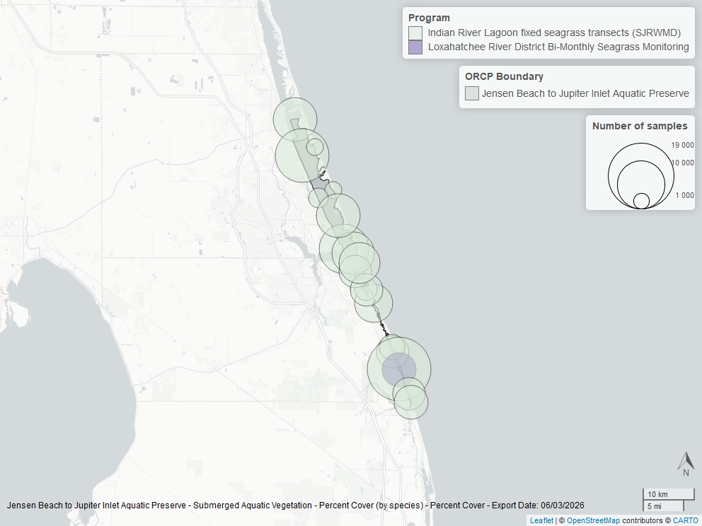

Map showing SAV sampling sites within the boundaries of *Jensen Beach to Jupiter Inlet Aquatic Preserve*. The point size reflects the number of samples at a given sampling site.

# Lemon Bay Aquatic Preserve

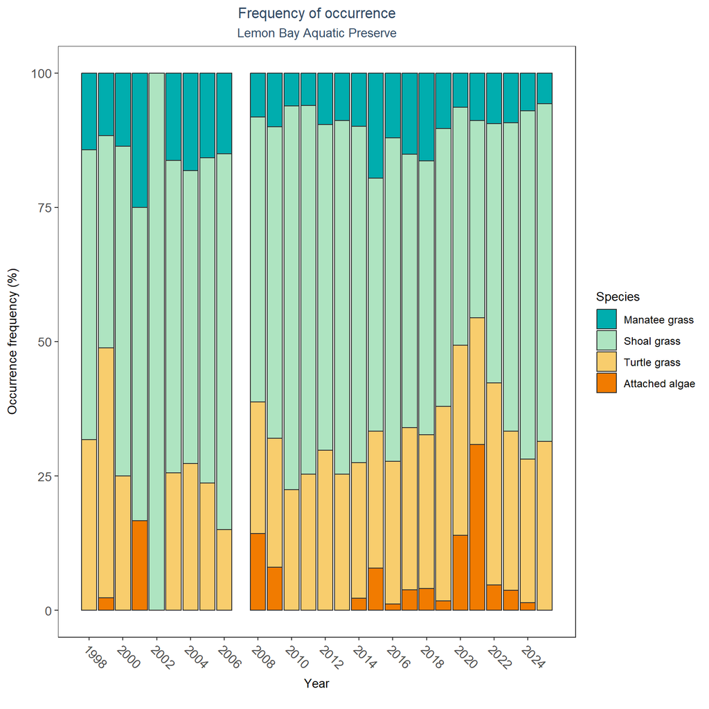

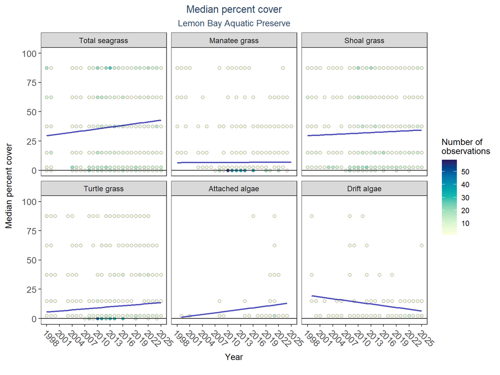

SAV LME Results for Lemon Bay Aquatic Preserve

| Species | Statistical Trend | Period of Record | LME Intercept | LME Slope | p |
| --- | --- | --- | --- | --- | --- |
| Attached algae | No detectable trend | 1999 - 2024 | -1.17 | 0.47 | 0.26 |
| Drift algae | Decreasing trend | 1999 - 2025 | 21.85 | -0.50 | 0.02 |
| Shoal grass | No detectable trend | 1998 - 2025 | 28.87 | 0.18 | 0.62 |
| Manatee grass | No detectable trend | 1998 - 2025 | 6.36 | 0.02 | 0.91 |
| Turtle grass | No detectable trend | 1998 - 2025 | 4.40 | 0.30 | 0.46 |
| Total seagrass | No detectable trend | 1998 - 2025 | 27.47 | 0.50 | 0.30 |

An annual decrease in percent cover was observed for drift algae (-0.50%). Total seagrass, manatee grass, shoal grass, turtle grass, and attached algae showed no detectable change in percent cover.

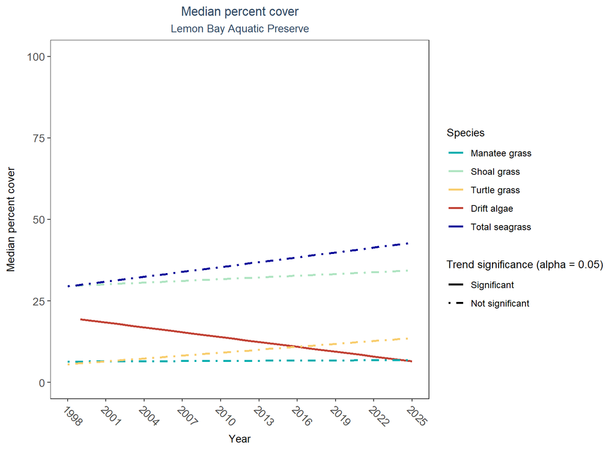

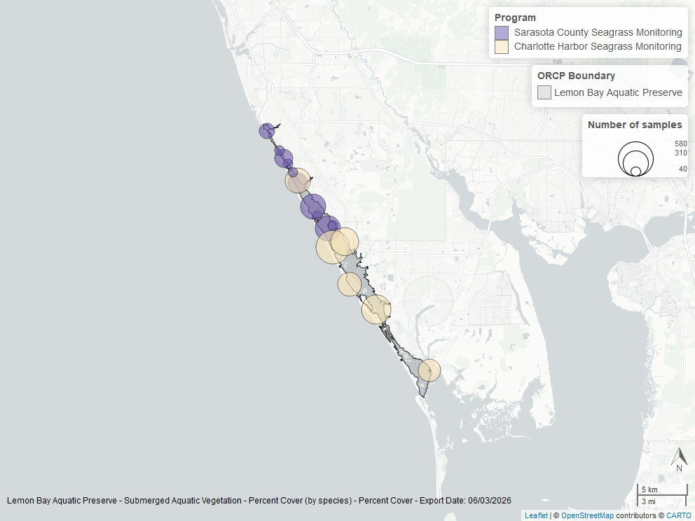

Map showing SAV sampling sites within the boundaries of *Lemon Bay Aquatic Preserve*. The point size reflects the number of samples at a given sampling site.

# Lignumvitae Key Aquatic Preserve

Not enough data to perform analyses in Lignumvitae Key Aquatic Preserve

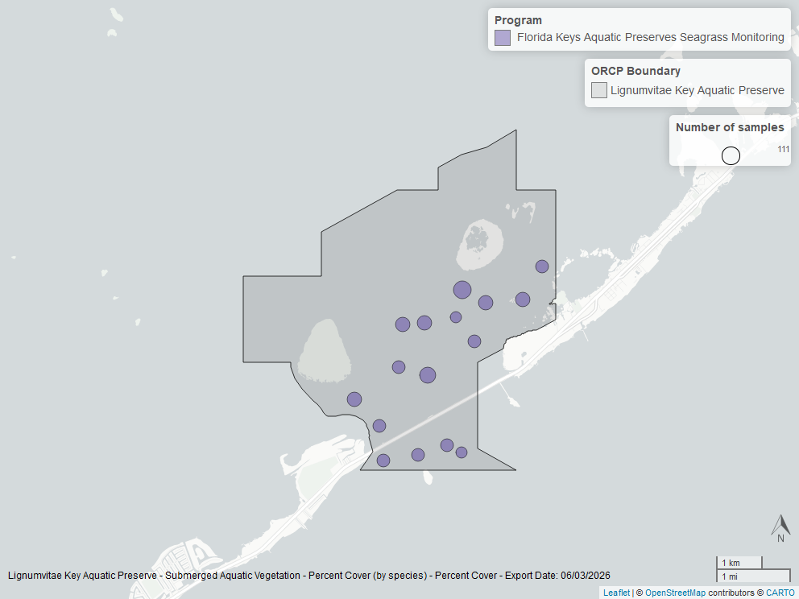

Map showing SAV sampling sites within the boundaries of *Lignumvitae Key Aquatic Preserve*. The point size reflects the number of samples at a given sampling site.

# Loxahatchee River-Lake Worth Creek Aquatic Preserve

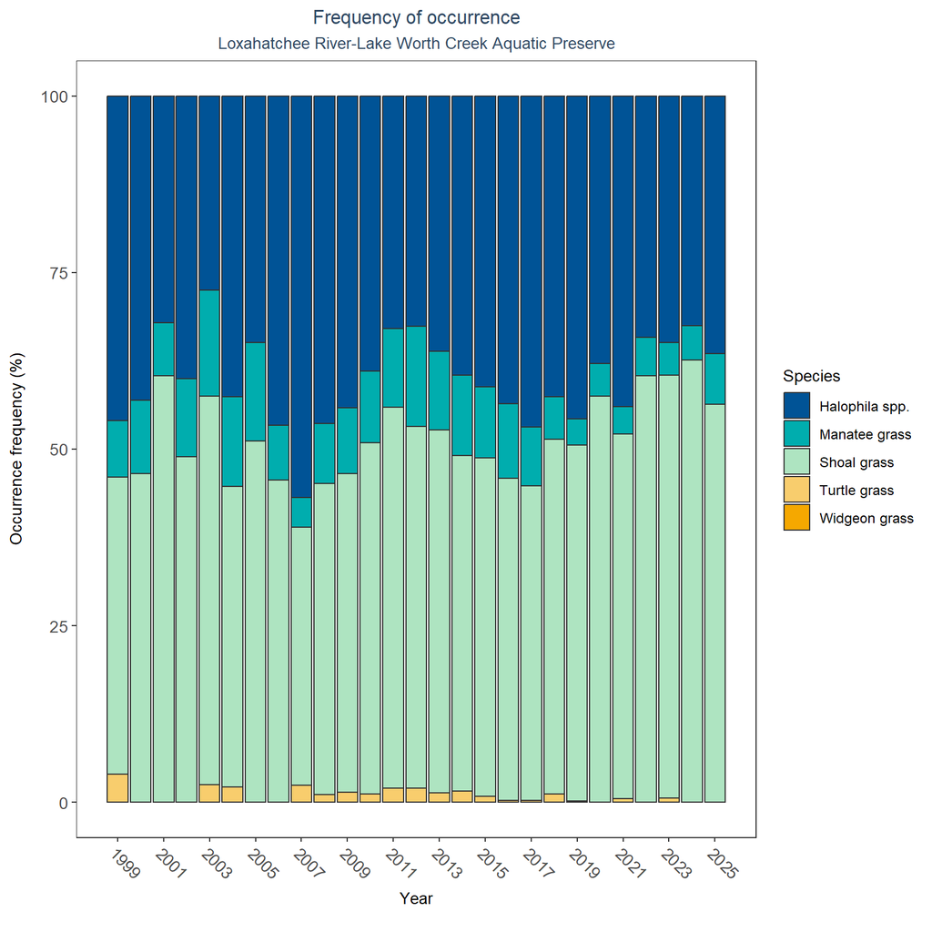

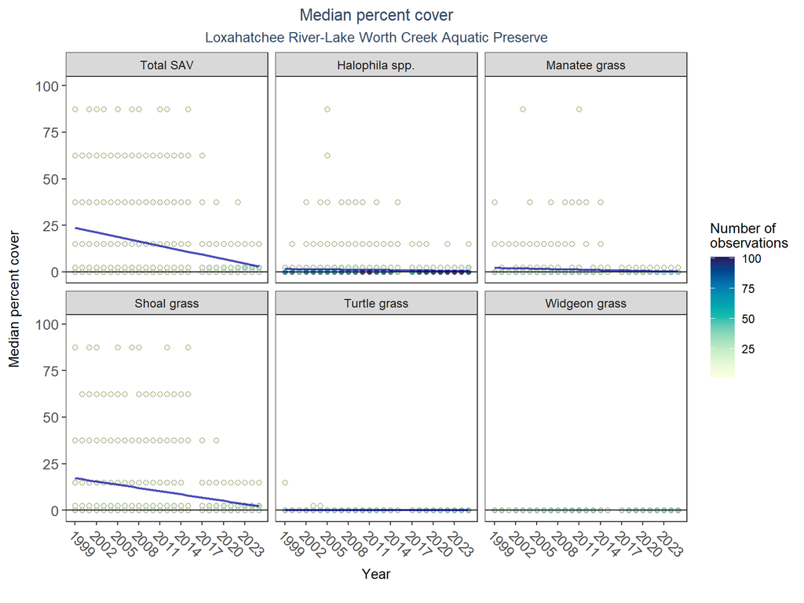

SAV LME Results for Loxahatchee River-Lake Worth Creek Aquatic Preserve

| Species | Statistical Trend | Period of Record | LME Intercept | LME Slope | p |
| --- | --- | --- | --- | --- | --- |
| Shoal grass | Decreasing trend | 1999 - 2025 | 20.20 | -0.58 | 0.00 |
| Halophila spp. | Decreasing trend | 1999 - 2025 | 1.71 | -0.04 | 0.00 |
| Widgeon grass | Model did not fit the available data | 1999 - 2025 | - | - | - |
| Manatee grass | No detectable trend | 1999 - 2025 | 2.54 | -0.08 | 0.34 |
| Turtle grass | No detectable trend | 1999 - 2025 | 0.09 | 0.00 | 0.30 |
| Total SAV | Decreasing trend | 1999 - 2025 | 27.66 | -0.80 | 0.00 |

Annual decreases in percent cover were observed for total SAV (-0.80%), *Halophila* spp. (-0.04%), and shoal grass (-0.58%). No detectable change in percent cover was observed for manatee grass and turtle grass. The model could not be fitted for widgeon grass.

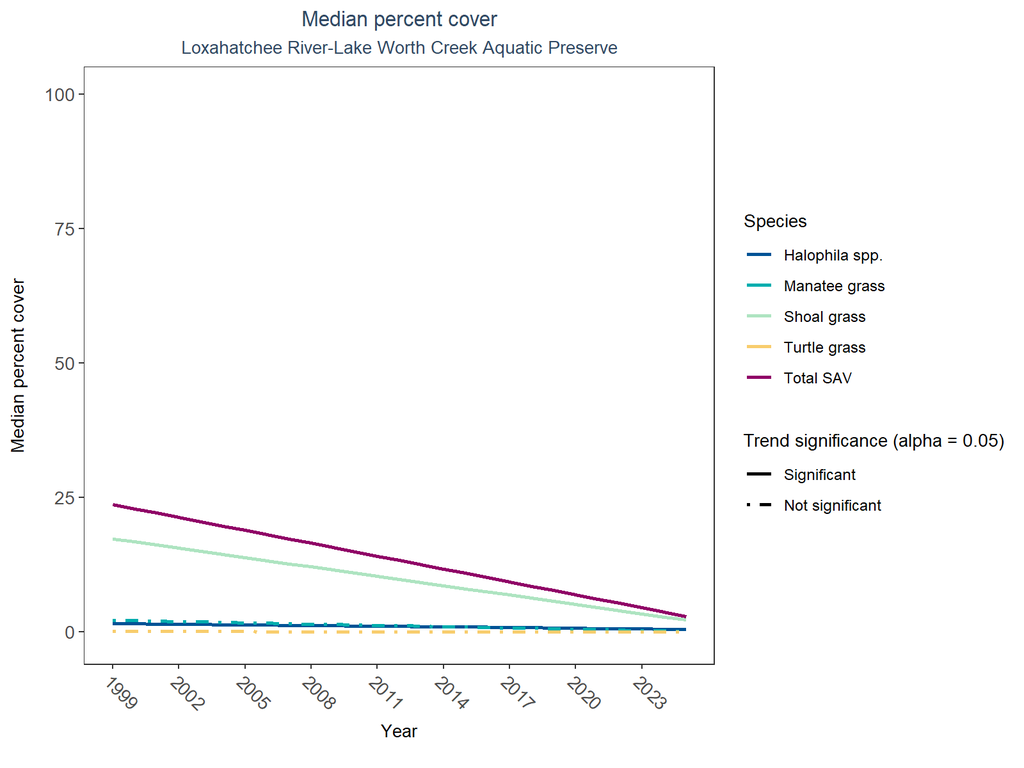

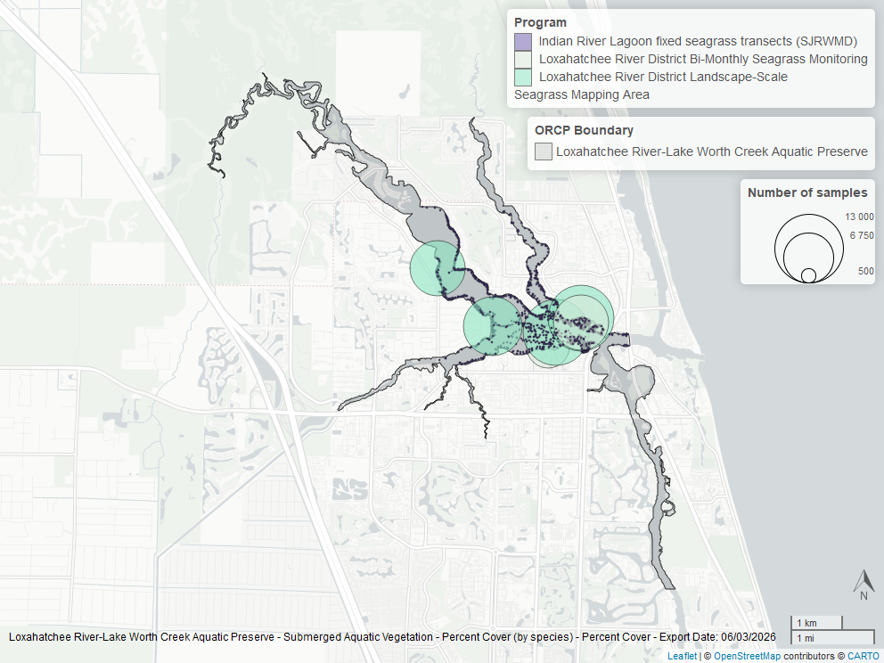

Map showing SAV sampling sites within the boundaries of *Loxahatchee River-Lake Worth Creek Aquatic Preserve*. The point size reflects the number of samples at a given sampling site.

# Matlacha Pass Aquatic Preserve

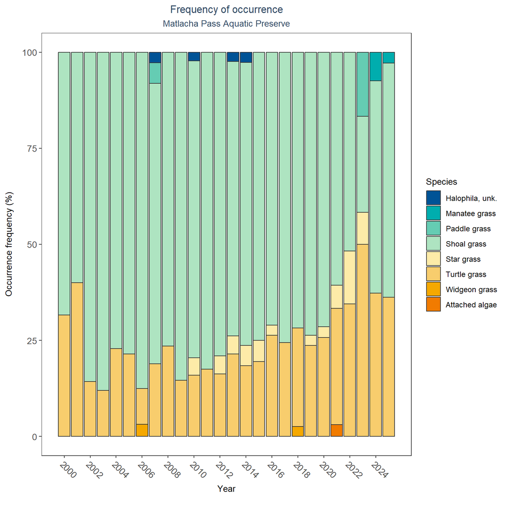

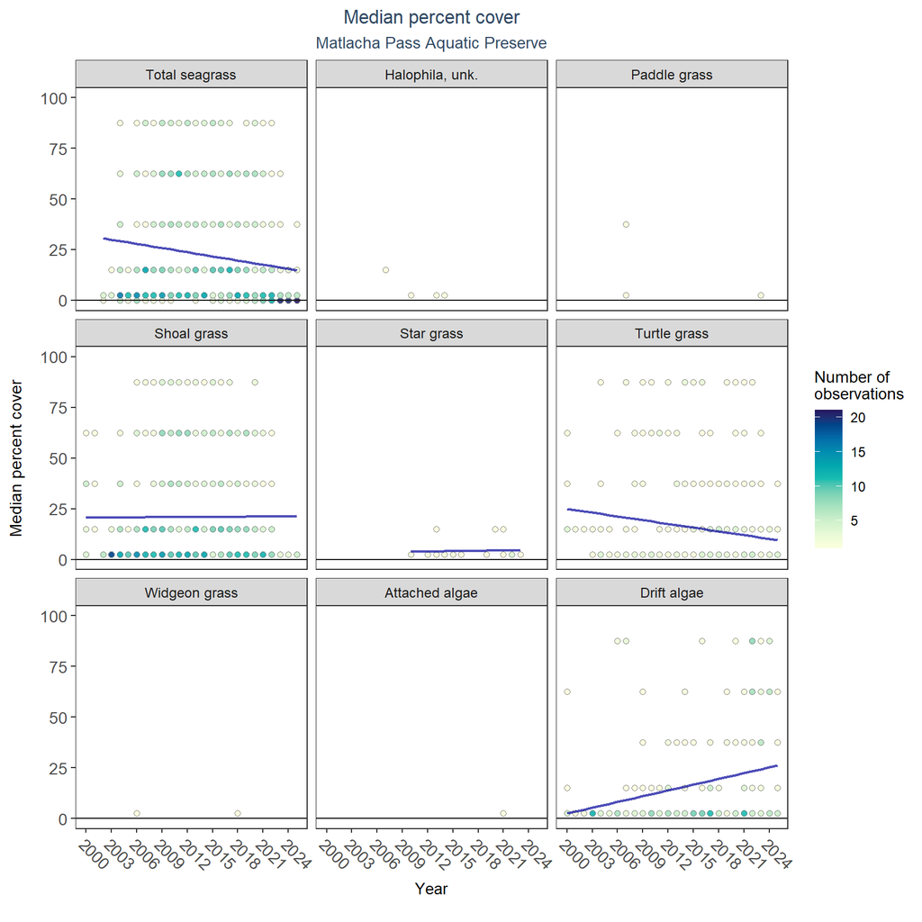

SAV LME Results for Matlacha Pass Aquatic Preserve

| Species | Statistical Trend | Period of Record | LME Intercept | LME Slope | p |
| --- | --- | --- | --- | --- | --- |
| Attached algae | Insufficient data | 2021 - 2021 | - | - | - |
| Drift algae | No detectable trend | 2000 - 2025 | -3.10 | 0.94 | 0.12 |
| Shoal grass | No detectable trend | 2000 - 2025 | 20.45 | 0.02 | 0.96 |
| Paddle grass | Insufficient data | 2007 - 2023 | - | - | - |
| Star grass | No detectable trend | 2010 - 2023 | 2.64 | 0.07 | 0.78 |
| Widgeon grass | Insufficient data | 2006 - 2018 | - | - | - |
| Turtle grass | No detectable trend | 2000 - 2025 | 28.66 | -0.62 | 0.05 |
| Total seagrass | Decreasing trend | 2002 - 2025 | 36.12 | -0.69 | 0.03 |
| Halophila, unk. | Insufficient data | 2007 - 2014 | - | - | - |

An annual decrease in percent cover was observed for total seagrass (-0.69%). Shoal grass, star grass, turtle grass, and drift algae showed no detectable change in percent cover. Trends in percent cover could not be evaluated for unknown *Halophila*, paddle grass, widgeon grass, and attached algae due to insufficient data.

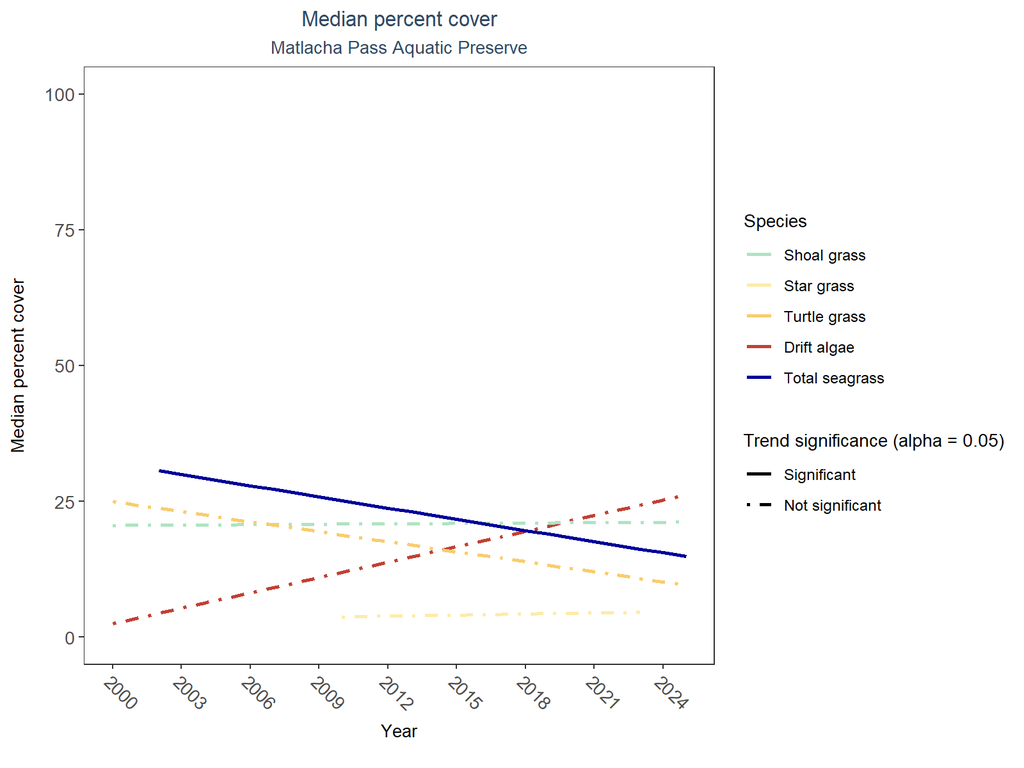

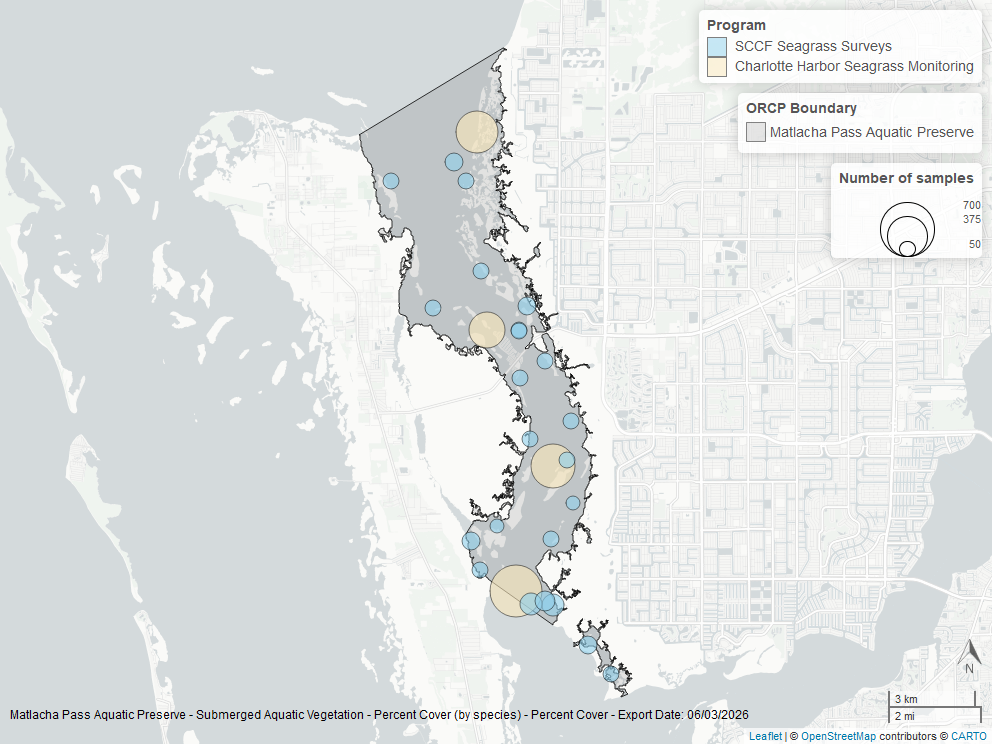

Map showing SAV sampling sites within the boundaries of *Matlacha Pass Aquatic Preserve*. The point size reflects the number of samples at a given sampling site.

# Mosquito Lagoon Aquatic Preserve

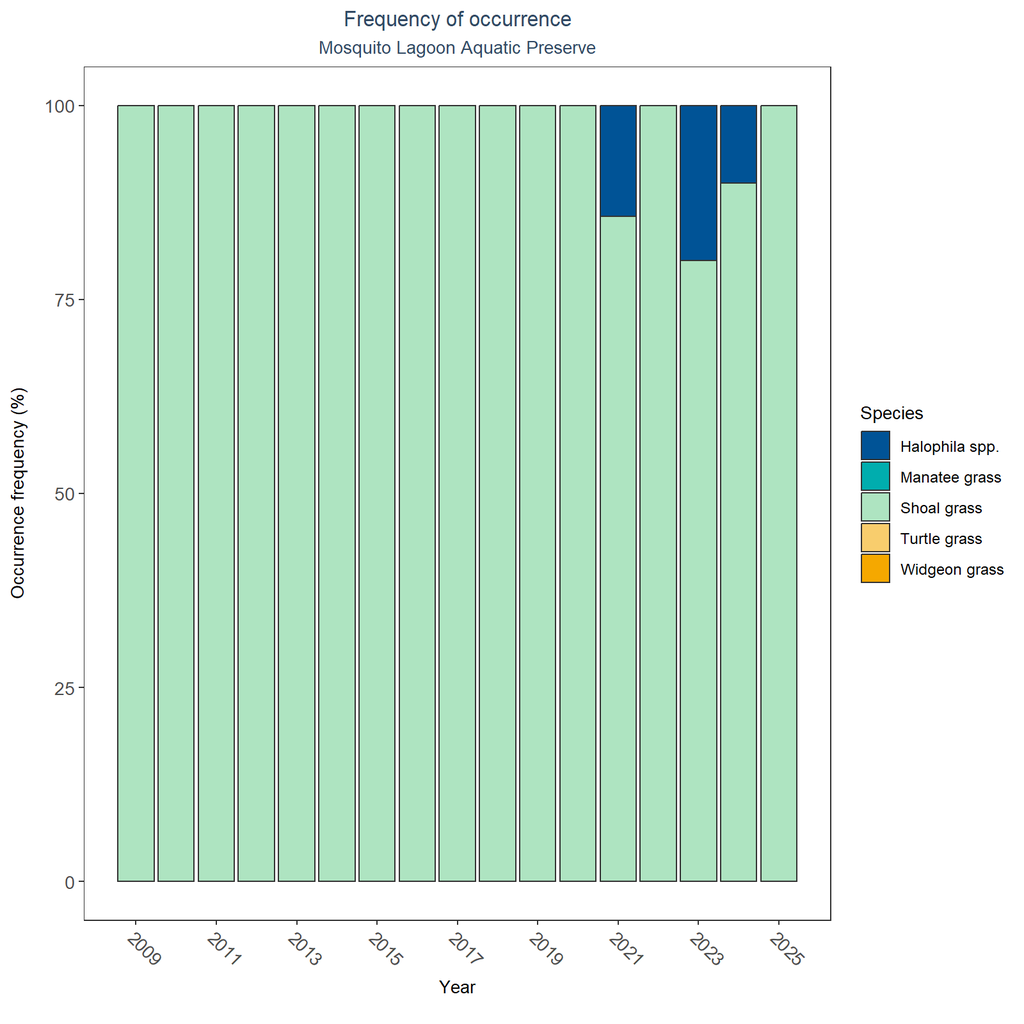

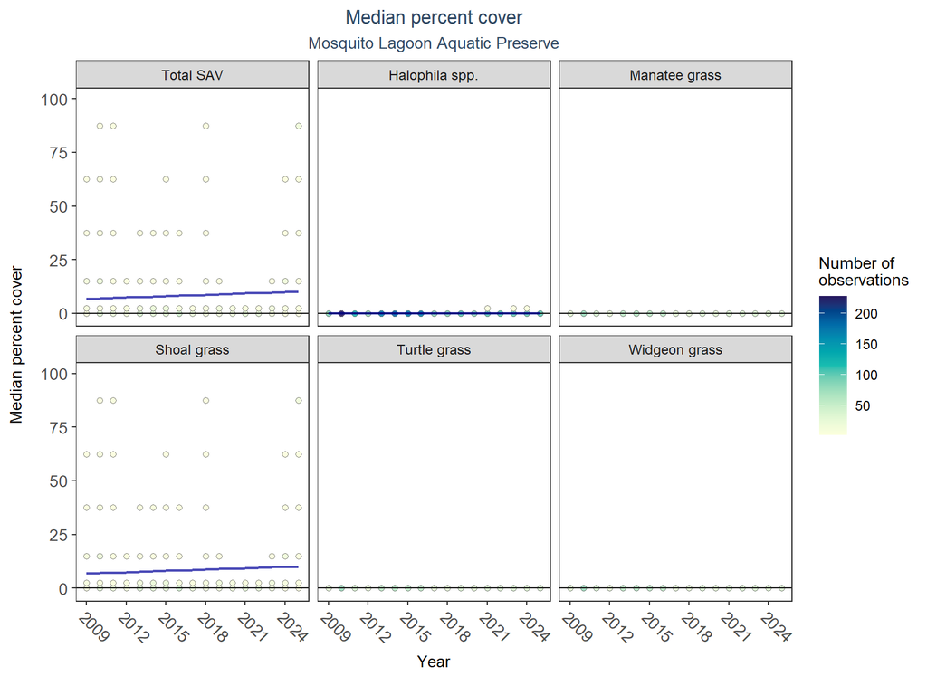

SAV LME Results for Mosquito Lagoon Aquatic Preserve

| Species | Statistical Trend | Period of Record | LME Intercept | LME Slope | p |
| --- | --- | --- | --- | --- | --- |
| Shoal grass | No detectable trend | 2009 - 2025 | 3.71 | 0.21 | 0.24 |
| Halophila spp. | No detectable trend | 2009 - 2025 | -0.05 | 0.00 | 0.16 |
| Widgeon grass | Model did not fit the available data | 2009 - 2025 | - | - | - |
| Manatee grass | Model did not fit the available data | 2009 - 2025 | - | - | - |
| Turtle grass | Model did not fit the available data | 2009 - 2025 | - | - | - |
| Total SAV | No detectable trend | 2009 - 2025 | 3.67 | 0.21 | 0.24 |

Total SAV, *Halophila* spp., and shoal grass showed no detectable change in percent cover. A model could not be fitted for manatee grass, turtle grass, and widgeon grass.

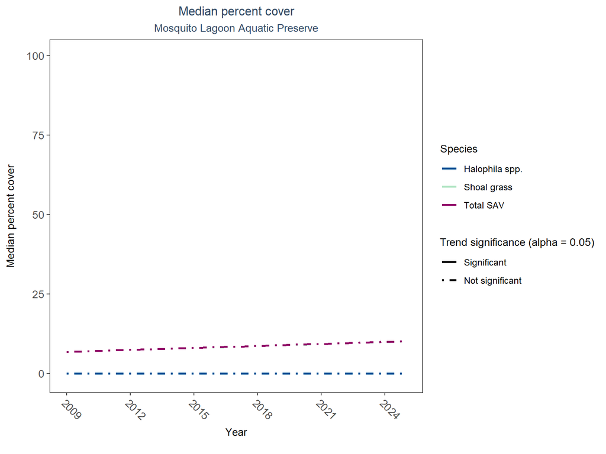

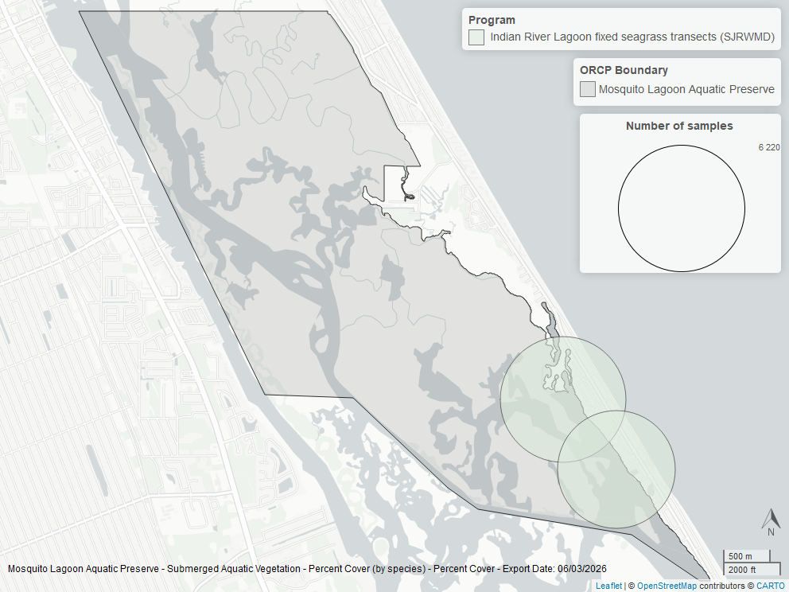

Map showing SAV sampling sites within the boundaries of *Mosquito Lagoon Aquatic Preserve*. The point size reflects the number of samples at a given sampling site.

# Nature Coast Aquatic Preserve

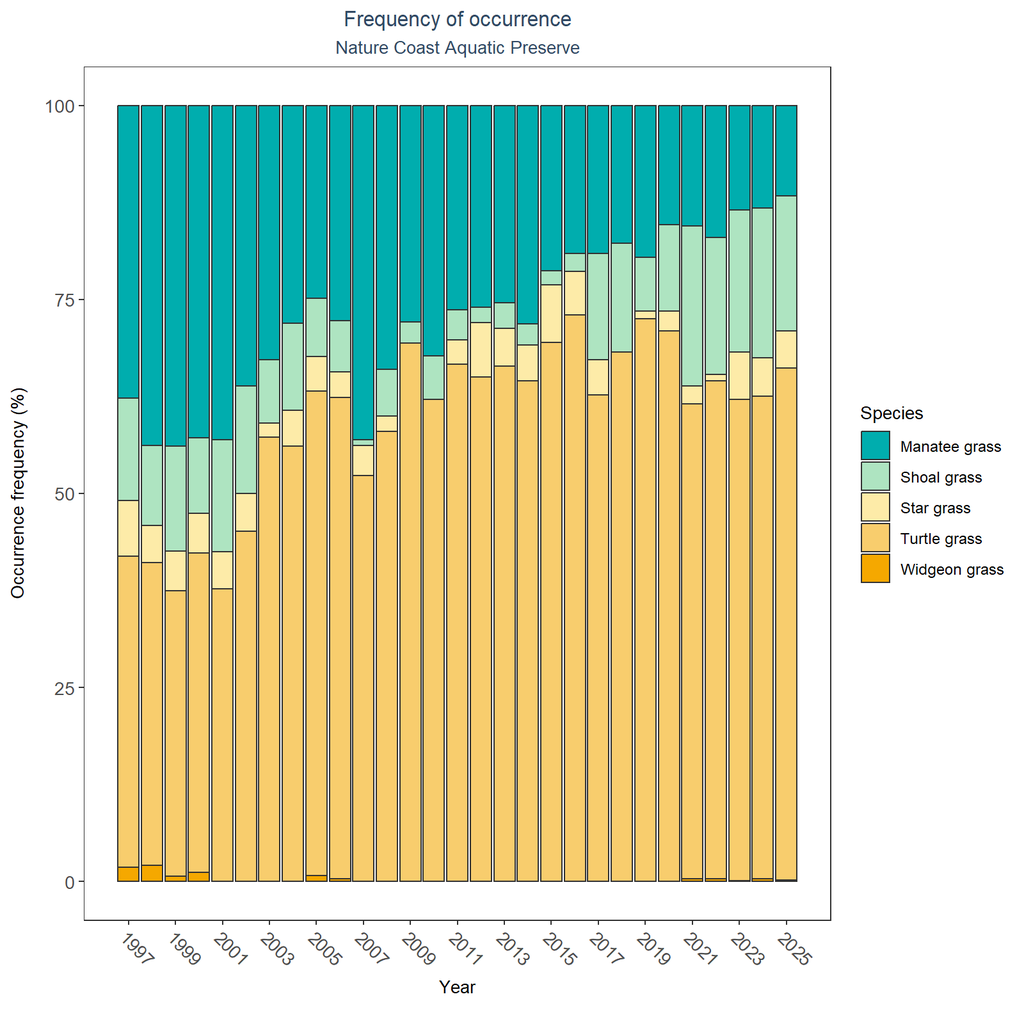

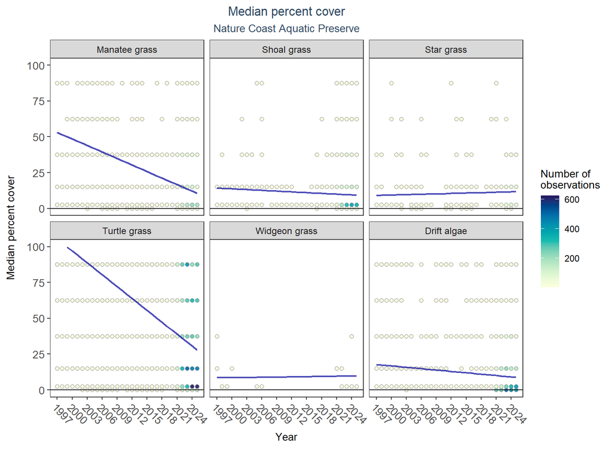

SAV LME Results for Nature Coast Aquatic Preserve

| Species | Statistical Trend | Period of Record | LME Intercept | LME Slope | p |
| --- | --- | --- | --- | --- | --- |
| Drift algae | No detectable trend | 1997 - 2025 | 18.72 | -0.32 | 0.42 |
| Shoal grass | Decreasing trend | 1997 - 2025 | 14.75 | -0.18 | 0.02 |
| Star grass | No detectable trend | 1997 - 2025 | 8.79 | 0.09 | 0.39 |
| Widgeon grass | No detectable trend | 1997 - 2025 | 8.39 | 0.04 | 0.97 |
| Manatee grass | Decreasing trend | 1997 - 2025 | 57.63 | -1.52 | 0.00 |
| Turtle grass | Decreasing trend | 1997 - 2025 | 113.58 | -2.76 | 0.00 |

Annual decreases in percent cover were observed for manatee grass (-1.52%), shoal grass (-0.18%), and turtle grass (-2.76%). Star grass, widgeon grass, and drift algae showed no detectable change in percent cover.

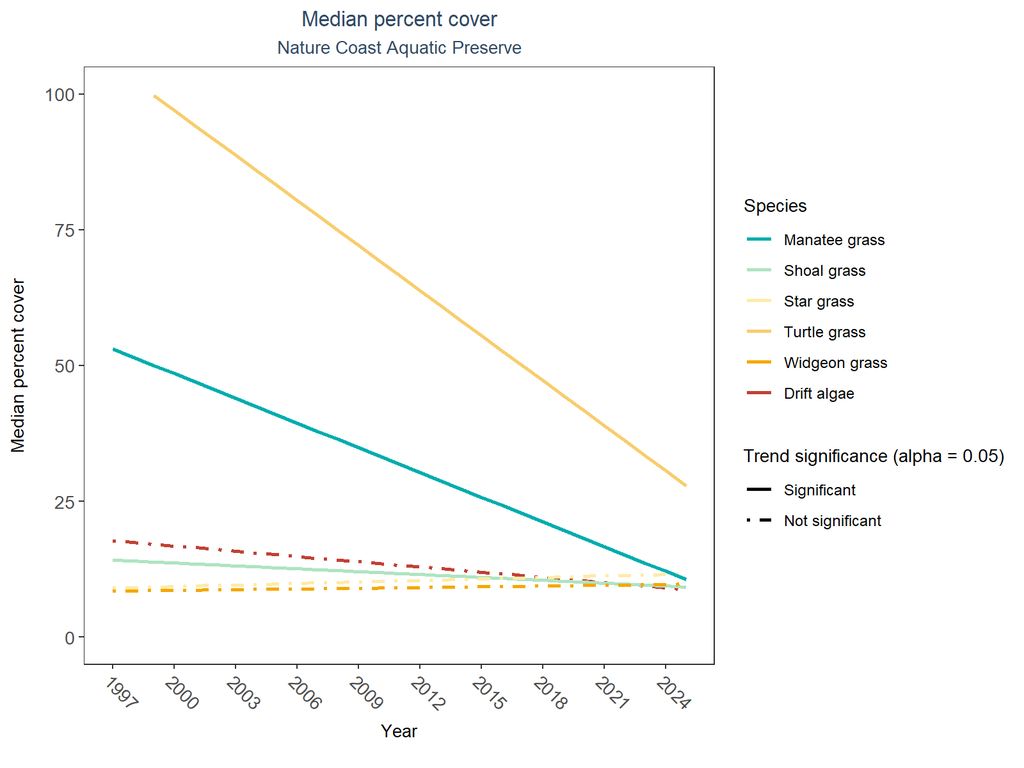

[figure not shown]

Map showing SAV sampling sites within the boundaries of *Nature Coast Aquatic Preserve*. The point size reflects the number of samples at a given sampling site.

# Pine Island Sound Aquatic Preserve

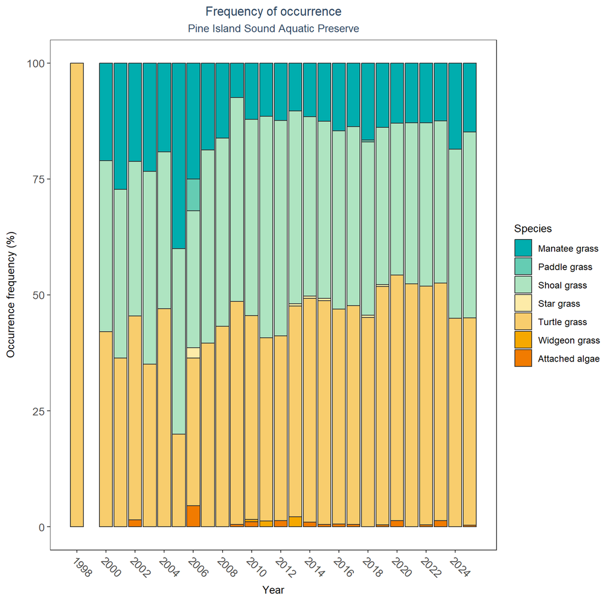

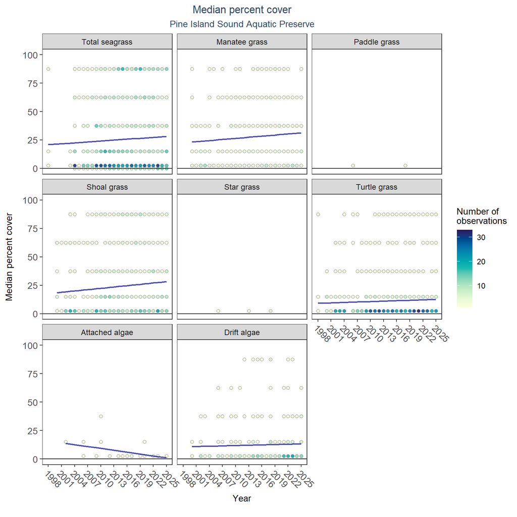

SAV LME Results for Pine Island Sound Aquatic Preserve

| Species | Statistical Trend | Period of Record | LME Intercept | LME Slope | p |
| --- | --- | --- | --- | --- | --- |
| Attached algae | No detectable trend | 2002 - 2025 | 18.16 | -0.55 | 0.05 |
| Drift algae | No detectable trend | 2000 - 2025 | 10.27 | 0.10 | 0.55 |
| Shoal grass | No detectable trend | 2000 - 2025 | 16.13 | 0.39 | 0.25 |
| Paddle grass | Insufficient data | 2006 - 2018 | - | - | - |
| Star grass | Insufficient data | 2006 - 2018 | - | - | - |
| Manatee grass | No detectable trend | 2000 - 2025 | 21.26 | 0.32 | 0.30 |
| Turtle grass | No detectable trend | 1998 - 2025 | 8.60 | 0.13 | 0.38 |
| Total seagrass | No detectable trend | 1998 - 2025 | 19.82 | 0.27 | 0.37 |

Total seagrass, manatee grass, shoal grass, turtle grass, attached algae, and drift algae showed no detectable change in percent cover. Trends in percent cover could not be evaluated for paddle grass and star grass due to insufficient data.

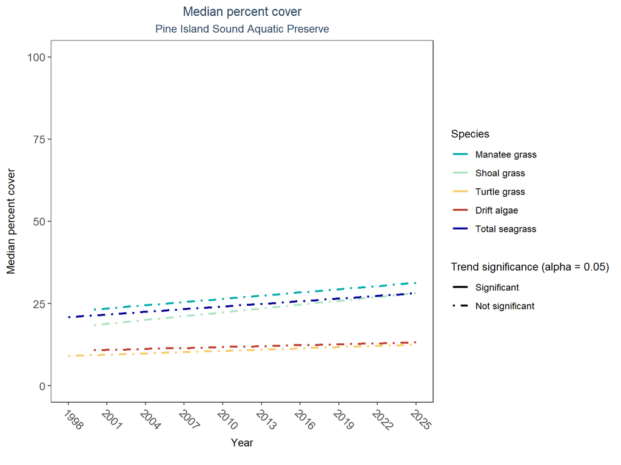

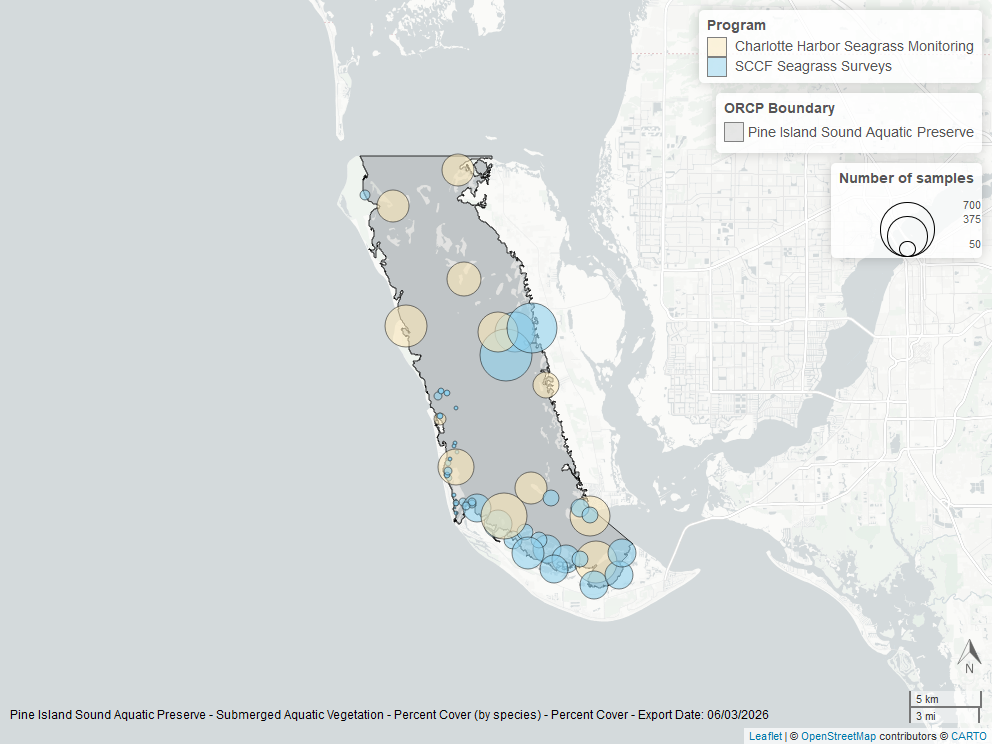

Map showing SAV sampling sites within the boundaries of *Pine Island Sound Aquatic Preserve*. The point size reflects the number of samples at a given sampling site.

# Pinellas County Aquatic Preserve

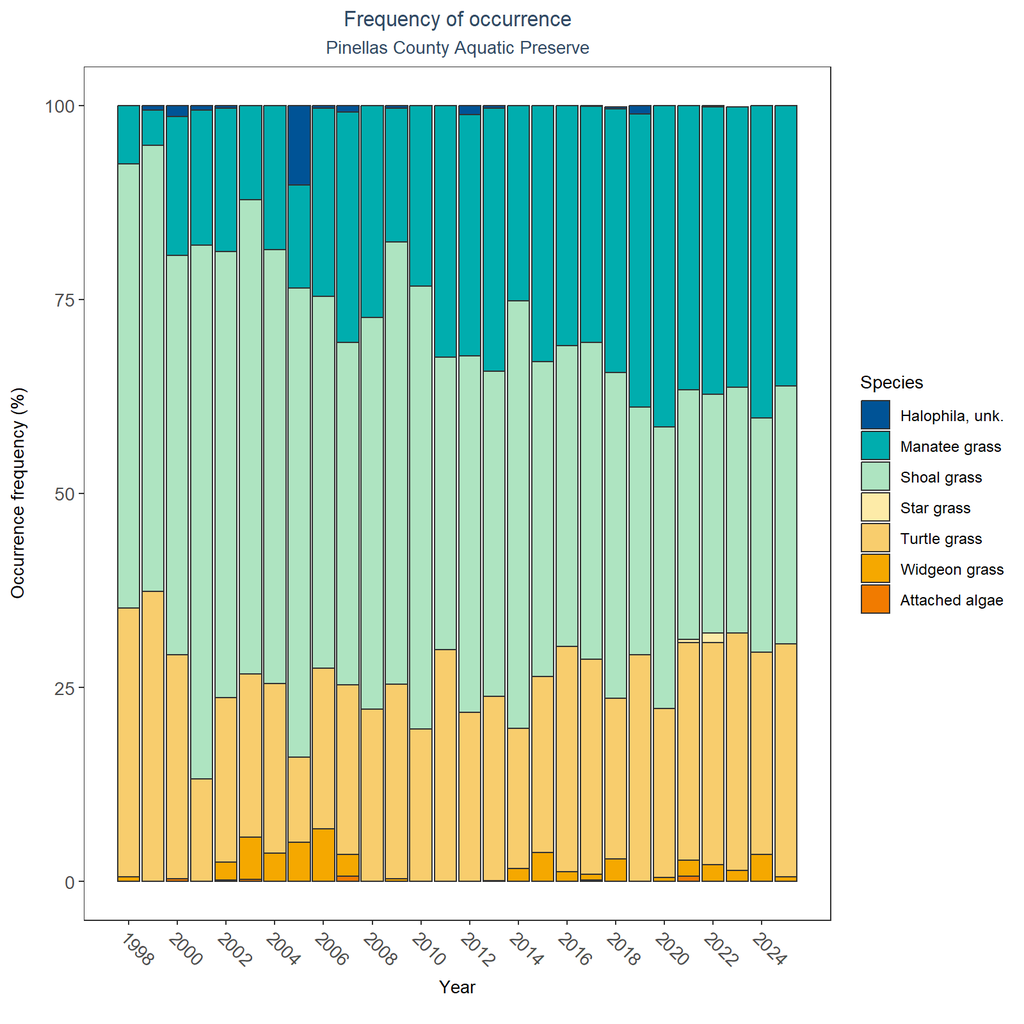

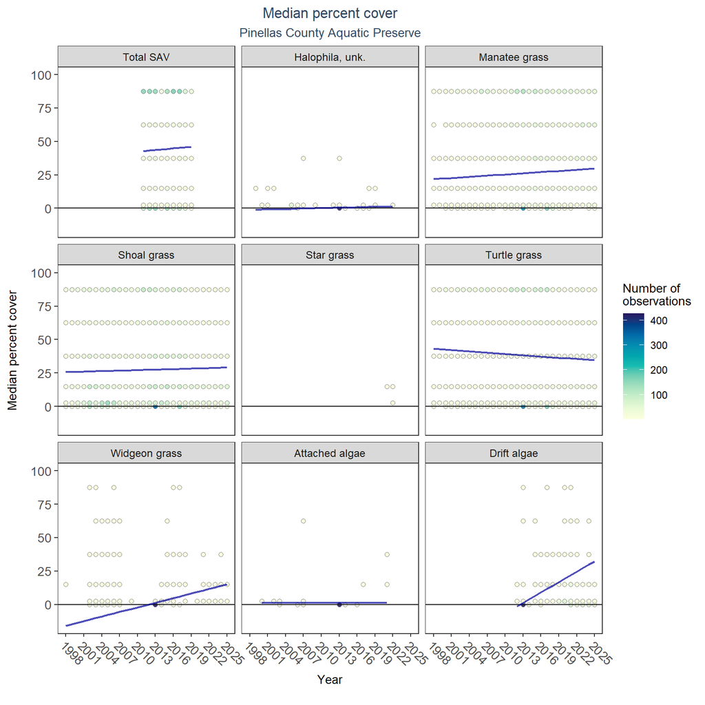

SAV LME Results for Pinellas County Aquatic Preserve

| Species | Statistical Trend | Period of Record | LME Intercept | LME Slope | p |
| --- | --- | --- | --- | --- | --- |
| Attached algae | No detectable trend | 2000 - 2021 | 1.35 | -0.01 | 0.96 |
| Drift algae | Increasing trend | 2012 - 2025 | -48.03 | 2.59 | 0.00 |
| Shoal grass | No detectable trend | 1998 - 2025 | 25.08 | 0.13 | 0.32 |
| Star grass | Insufficient data | 2021 - 2022 | - | - | - |
| Widgeon grass | No detectable trend | 1998 - 2025 | -20.51 | 1.15 | 0.37 |
| Manatee grass | No detectable trend | 1998 - 2025 | 20.60 | 0.29 | 0.14 |
| Turtle grass | No detectable trend | 1998 - 2025 | 44.35 | -0.32 | 0.05 |
| Total SAV | No detectable trend | 2011 - 2019 | 35.61 | 0.42 | 0.57 |
| Halophila, unk. | No detectable trend | 1999 - 2022 | -1.64 | 0.11 | 0.66 |

An annual increase in percent cover was observed for drift algae (2.59%). Total SAV, unknown *Halophila*, manatee grass, shoal grass, turtle grass, widgeon grass, and attached algae showed no detectable change in percent cover. Trends in percent cover could not be evaluated for star grass due to insufficient data.

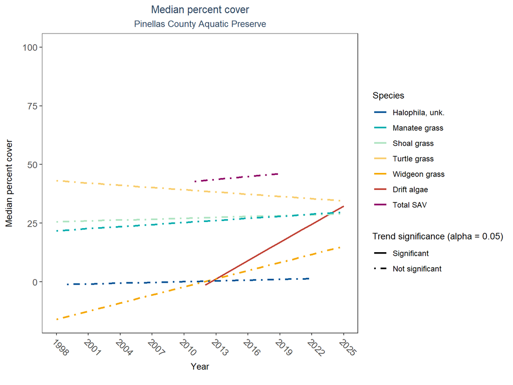

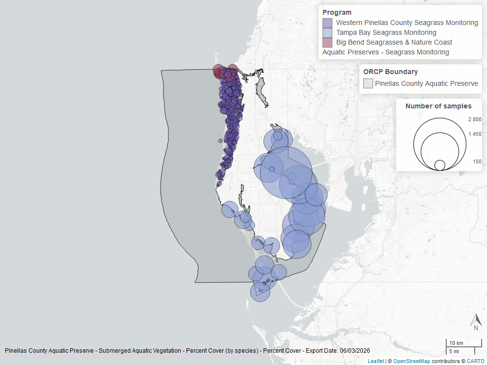

Map showing SAV sampling sites within the boundaries of *Pinellas County Aquatic Preserve*. The point size reflects the number of samples at a given sampling site.

# Rookery Bay Aquatic Preserve

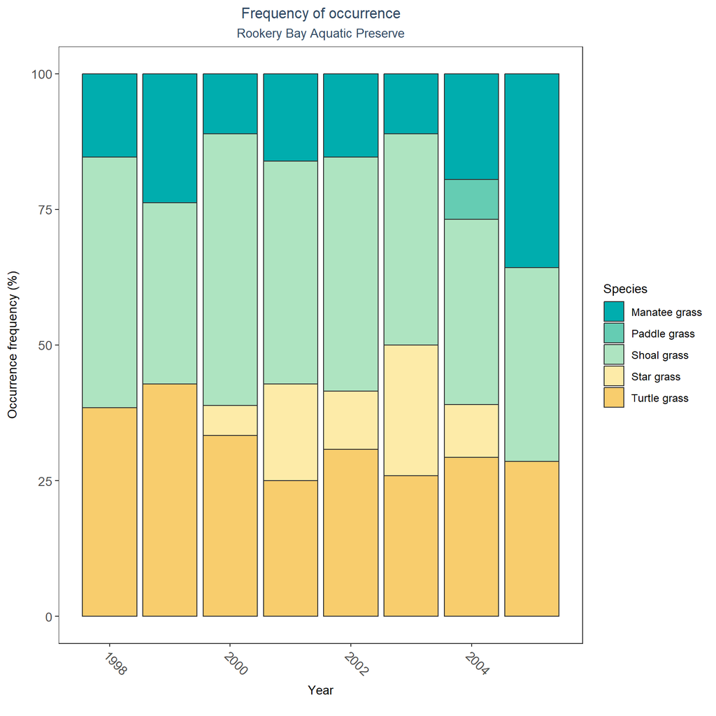

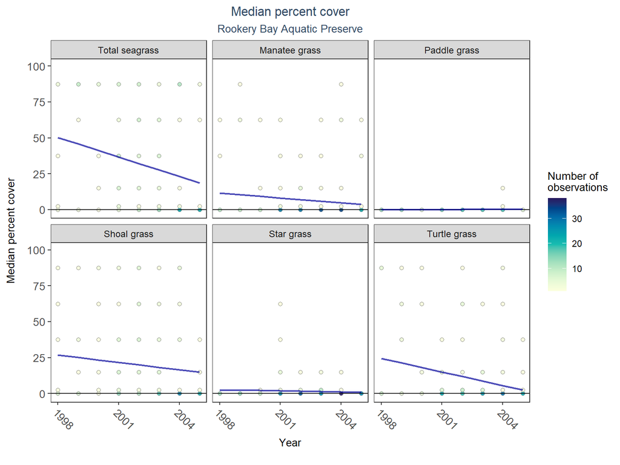

SAV LME Results for Rookery Bay Aquatic Preserve

| Species | Statistical Trend | Period of Record | LME Intercept | LME Slope | p |
| --- | --- | --- | --- | --- | --- |
| Shoal grass | No detectable trend | 1998 - 2005 | 33.63 | -1.71 | 0.25 |
| Paddle grass | No detectable trend | 1998 - 2005 | -0.44 | 0.08 | 0.36 |
| Star grass | No detectable trend | 1998 - 2005 | 3.53 | -0.23 | 0.44 |
| Manatee grass | No detectable trend | 1998 - 2005 | 16.10 | -1.13 | 0.40 |
| Turtle grass | No detectable trend | 1998 - 2005 | 36.99 | -3.14 | 0.07 |
| Total seagrass | Decreasing trend | 1998 - 2005 | 68.37 | -4.52 | 0.02 |

An annual decrease in percent cover was observed for total seagrass (-4.52%). Manatee grass, paddle grass, shoal grass, star grass, and turtle grass showed no detectable change in percent cover.

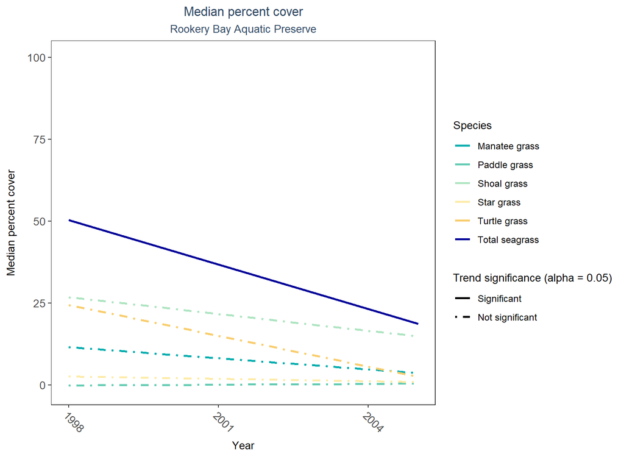

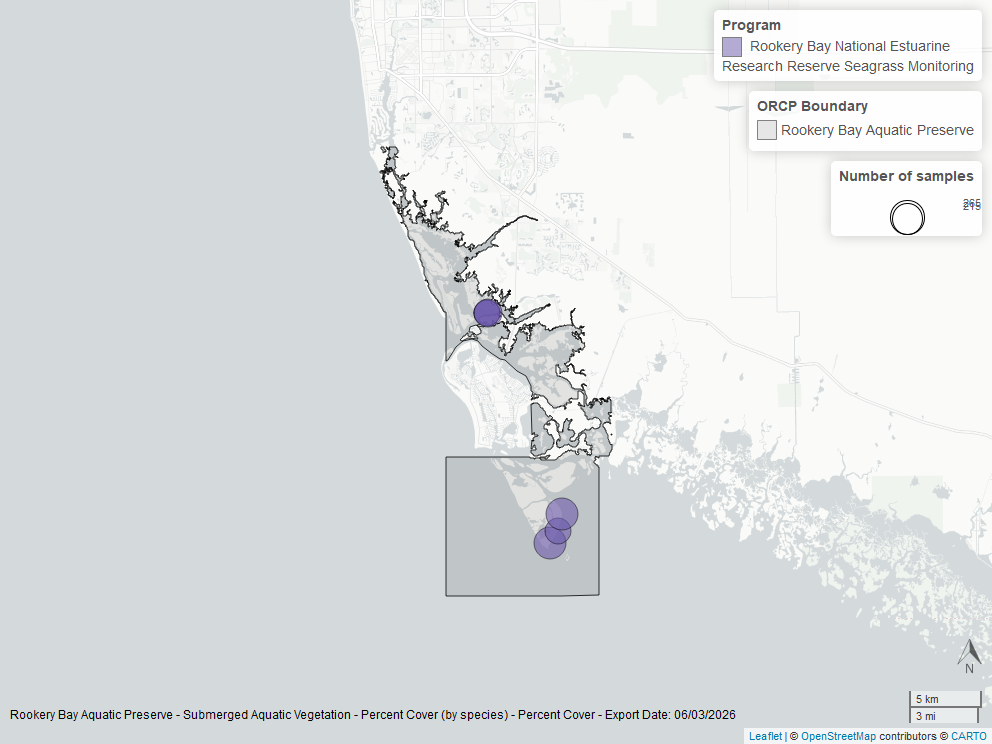

Map showing SAV sampling sites within the boundaries of *Rookery Bay Aquatic Preserve*. The point size reflects the number of samples at a given sampling site.